# Piru_enchancement-Models

Kit Swift

2022-12-15

# Load libraries

```r
library(here) # similar to set working directory
library(tidyverse) # data wrangling
library(lubridate) # dates and times
library(ggthemes)
library(plotly)
library(dplyr)
library(olsrr)
#library(survival)
library(lme4)
library(lmerTest)
library(multcomp)
library(multcompView)
library(emmeans)
library(multcomp) # functions: multcompLetters2, multcompLetters3, multcompLetters4 using aov object

#mafa_cover_all = MAFA % cover 2018 and 2019
#exotic_cover_all = exotic % cover 2018 and 2019
```

# Load colors for graphs

```r
devtools::install_github("an-bui/calecopal")
library(calecopal)
# all palettes
names(cal_palettes)
```

```
##  [1] "sierra1"      "sierra2"      "chaparral1"   "chaparral2"   "chaparral3"
##  [6] "conifer"      "desert"       "wetland"      "oak"          "kelp1"
## [11] "kelp2"        "coastaldune1" "coastaldune2" "superbloom1"  "superbloom2"
## [16] "superbloom3"  "sbchannel"    "lake"         "fire"         "agriculture"
## [21] "bigsur"       "figmtn"       "caqu"         "eschscholzia" "arbutus"
## [26] "calochortus"  "grassdry"     "grasswet"     "sage"         "tidepool"
## [31] "seagrass"     "bigsur2"      "bixby"        "redwood1"     "redwood2"
## [36] "halfdome"     "creek"        "vermillion"   "canary"       "casj"
## [41] "lupinus"      "dudleya"      "gayophytum"   "collinsia"    "buow"
```

```r
# Site colors: 1, 2
cal_palette(name = "chaparral1", n = 5, type = "continuous") # [1] "#DCC27A" "#F19B34"
```

```
## [1] "#DCC27A" "#9CA2A6" "#7D5F5D" "#A8A694" "#F19B34"
## attr(,"class")
## [1] "palette"
## attr(,"name")
## [1] "chaparral1"
```

```r
site1color <- "#DCC27A"
site2color <- "#F19B34"
sitecolors <- c(site1color, site2color)

# Treatment colors: Full, half, none
cal_palette(name = "chaparral3", n = 5, type = "continuous") # [1] "#D3E3CA", "#92A587", "#2F3525"
```

```
## [1] "#D3E3CA" "#BED6B3" "#92A587" "#4A5438" "#2F3525"
## attr(,"class")
## [1] "palette"
## attr(,"name")
## [1] "chaparral3"
```

```r
cal_palette(name = "desert", n = 5, type = "continuous") # [1] "#F6EECF", "#B09175", "#291611"
```

```
## [1] "#F6EECF" "#ECD6AB" "#B09175" "#632D1F" "#291611"
## attr(,"class")
## [1] "palette"
## attr(,"name")
## [1] "desert"
```

```r
treatment1color <- "#F6EECF"
treatment2color <- "#B09175"
treatment3color <- "#291611"
treatmentcolors <- c(treatment1color, treatment2color, treatment3color)
```

# Question 1: How do environmental conditions change by a) canopy treatment and b) canopy cover?

Is canopy treatment or canopy cover a stronger predictor of the environmental conditions below the shrub canopy?

Notes: - **response variable**: The variable you want to test. (e.g.,. PAR, TDR, nncover) - **explanatory variables**: The variables that can explain the outcome. (e.g., treatment, mafacover, site) - **data frame**: Include all the data you’ll be working with. (e.g., combine par and mafa_cover_all) - **formula**: a formula is a two-sided linear formula object describing both the *fixed-effects* and *random effects* part of the model, with the response on the left of a ~ operator and the terms, separated by + operators, on the right. - **random effects**: Random-effects terms are distinguished by vertical bars **(|)** separating expressions for design matrices from grouping factors. Two vertical bars **(||)** can be used to specify multiple uncorrelated random effects for the same grouping variable. + Because of the way it is implemented, the ||-syntax works only for design matrices containing numeric (continuous) predictors; to fit models with independent categorical effects, see dummy or the lmer_alt function from the afex package.)

### Load PAR, TDR, and non-native percent cover data.

### Saved as a csv in the “Processed” data folder.

```r
# variables as characters
# data as double numbers
mafa_cover_all_load <- read_csv("data/processed/mafa_cover_all.csv",
  col_types = cols(
    plot_number = col_character(),
    year = col_character(),
    cover_percent = col_double(),
    site = col_character()
    )
  )
mafa_cover_all <- mafa_cover_all_load %>%
  dplyr::select(plot_number, year, cover_percent, site)

par_load <- read_csv("data/processed/par.csv",
  col_types = cols(
    date = col_character(),
    plot_number = col_character(),
    treatment = col_character(),
    year = col_character(),
    month = col_character(),
    site = col_character(),
    normalized_par = col_double()
    )
  )
par <- par_load %>%
  dplyr::select(date, year, month, site, plot_number, treatment, normalized_par)

tdr_load <- read_csv("data/processed/tdr.csv",
  col_types = cols(
    plot_number = col_character(),
    treatment = col_character(),
    year = col_character(),
    month = col_character(),
    site = col_character(),
    soil_moisture = col_double()
    )
  )
tdr <- tdr_load %>%
  dplyr::select(date, year, month, site, plot_number, treatment, soil_moisture)

exotic_cover_all_load <- read_csv("data/processed/exotic_cover_all.csv",
    col_types = cols(
    year = col_character(),
    plot_number = col_character(),
    MAFA_removal = col_character(),
    site = col_character(),
    cover_percent = col_double()
    )
)
exotic_cover_all <- exotic_cover_all_load %>%
  dplyr::select(date, year, site, plot_number, MAFA_removal, cover_percent)

survmort_load <- read_csv("data/processed/survmort.csv",
                          col_types = cols(
                             year = col_character(),
                             month = col_character(),
                             plot_number = col_character(),
                             treatment = col_character(),
                             species = col_character(),
                             alive = col_integer(),
                             dead = col_integer(),
                             site = col_character(),
                             month_count = col_integer(),
                             transplanted = col_character()
                          )
                          )
survmort <- survmort_load %>%
  dplyr::select(year, month, plot_number, treatment, species, alive, dead, site, month_count, transplanted)
print(survmort)
```

```
## # A tibble: 2,017 × 10
##    year  month plot_number treatment species alive  dead site  month_count
##    <chr> <chr> <chr>       <chr>     <chr>   <int> <int> <chr>       <int>
##  1 2018  1     1           none      CEOL        4     0 1               0
##  2 2018  1     1           none      HEAR        6     0 1               0
##  3 2018  1     1           none      RHOV        4     0 1               0
##  4 2018  1     1           none      SAAP        4     0 1               0
##  5 2018  1     2           full      CEOL        4     0 1               0
##  6 2018  1     2           full      HEAR        6     0 1               0
##  7 2018  1     2           full      RHOV        4     0 1               0
##  8 2018  1     2           full      SAAP        4     0 1               0
##  9 2018  1     3           full      CEOL        4     0 1               0
## 10 2018  1     3           full      HEAR        6     0 1               0
## # … with 2,007 more rows, and 1 more variable: transplanted <chr>
```

```r
summary(survmort)
```

```
##      year              month           plot_number         treatment
##  Length:2017        Length:2017        Length:2017        Length:2017
##  Class :character   Class :character   Class :character   Class :character
##  Mode  :character   Mode  :character   Mode  :character   Mode  :character
##
##
##
##    species              alive            dead           site
##  Length:2017        Min.   :0.000   Min.   :0.000   Length:2017
##  Class :character   1st Qu.:0.000   1st Qu.:0.000   Class :character
##  Mode  :character   Median :1.000   Median :2.000   Mode  :character
##                     Mean   :1.362   Mean   :1.879
##                     3rd Qu.:3.000   3rd Qu.:3.000
##                     Max.   :6.000   Max.   :6.000
##   month_count    transplanted
##  Min.   : 0.00   Length:2017
##  1st Qu.:11.00   Class :character
##  Median :16.00   Mode  :character
##  Mean   :17.26
##  3rd Qu.:26.00
##  Max.   :39.00
```

```r
# PAR
parmod <- par %>%
  left_join(mafa_cover_all, by = c("year", "site", "plot_number"), na.rm = F) %>%
  rename(mafacover = cover_percent)
print(parmod)
```

```
## # A tibble: 288 × 8
##    date       year  month site  plot_number treatment normalized_par mafacover
##    <chr>      <chr> <chr> <chr> <chr>       <chr>              <dbl>     <dbl>
##  1 2018-04-26 2018  4     1     1           no                 0.225        42
##  2 2018-04-26 2018  4     1     2           full               0.339        10
##  3 2018-04-26 2018  4     1     3           full               0.167         9
##  4 2018-04-26 2018  4     1     4           half               0.311        23
##  5 2018-04-26 2018  4     1     5           half               0.482        12
##  6 2018-04-26 2018  4     1     6           no                 0.218        35
##  7 2018-04-26 2018  4     1     7           no                 0.244        28
##  8 2018-04-26 2018  4     1     8           half               0.233        17
##  9 2018-04-26 2018  4     1     9           full               0.451        15
## 10 2018-04-26 2018  4     1     10          half               0.422        27
## # … with 278 more rows
```

```r
parmod %>%
  group_by(year, treatment) %>%
  summarise(N = length(normalized_par))
```

```
## # A tibble: 6 × 3
## # Groups:   year [2]
##   year  treatment     N
##   <chr> <chr>     <int>
## 1 2018  full         24
## 2 2018  half         24
## 3 2018  no           24
## 4 2019  full         72
## 5 2019  half         72
## 6 2019  no           72
```

```r
# TDR
tdrmod <- tdr %>%
  left_join(mafa_cover_all, by = c("year", "site", "plot_number"), na.rm = F) %>%
  rename(mafacover = cover_percent) %>%
  filter(year <= 2019)
print(tdrmod)
```

```
## # A tibble: 108 × 8
##    date       year  month site  plot_number treatment soil_moisture mafacover
##    <date>     <chr> <chr> <chr> <chr>       <chr>             <dbl>     <dbl>
##  1 2018-04-19 2018  4     2     19          full               6.87      0
##  2 2018-04-19 2018  4     2     20          none               6.4      27
##  3 2018-04-19 2018  4     2     21          half               8.17     23
##  4 2018-04-19 2018  4     2     22          full               9.7       2
##  5 2018-04-19 2018  4     2     23          half              10.0      20
##  6 2018-04-19 2018  4     2     24          none               8.97     28
##  7 2018-04-19 2018  4     2     25          none               7.8      10
##  8 2018-04-19 2018  4     2     26          half               7.07     11
##  9 2018-04-19 2018  4     2     27          full               8.43      2.25
## 10 2018-04-19 2018  4     2     28          half               6.93      0
## # … with 98 more rows
```

```r
tdrmod %>%
  group_by(year, treatment) %>%
  summarise(N = length(soil_moisture))
```

```
## # A tibble: 6 × 3
## # Groups:   year [2]
##   year  treatment     N
##   <chr> <chr>     <int>
## 1 2018  full         24
## 2 2018  half         24
## 3 2018  none         24
## 4 2019  full         12
## 5 2019  half         12
## 6 2019  none         12
```

```r
# write.csv(tdrmod, "data/processed/tdr_model.csv")
# tdr1 <- filter(tdrmod, site == "1")
# tdr2 <- filter(tdrmod, site == "2")

# NN COVER
nnmod <- exotic_cover_all %>%
   left_join(mafa_cover_all, by = c("year", "site", "plot_number"), na.rm = F) %>%
  rename(nncover = cover_percent.x,
         mafacover = cover_percent.y,
         treatment = MAFA_removal) #%>%
  # dplyr::select("date", "year", "site", "plot_number", "treatment", "nncover", "mafacover")
print(nnmod)
```

```
## # A tibble: 72 × 7
##    date       year  site  plot_number treatment nncover mafacover
##    <date>     <chr> <chr> <chr>       <chr>       <dbl>     <dbl>
##  1 2018-05-26 2018  1     1           none         22          42
##  2 2018-05-26 2018  1     2           full         48          10
##  3 2018-06-04 2018  1     3           full         63           9
##  4 2018-06-04 2018  1     4           half         39.5        23
##  5 2018-05-26 2018  1     5           half         38          12
##  6 2018-05-26 2018  1     6           none         43          35
##  7 2018-06-04 2018  1     7           none         25          28
##  8 2018-05-26 2018  1     8           half         50          17
##  9 2018-05-26 2018  1     9           full         43          15
## 10 2018-05-26 2018  1     10          half         31.1        27
## # … with 62 more rows
```

```r
nnmod %>%  # check number of data points
  group_by(year, treatment) %>%
  summarise(N = length(mafacover))
```

```
## # A tibble: 6 × 3
## # Groups:   year [2]
##   year  treatment     N
##   <chr> <chr>     <int>
## 1 2018  full         12
## 2 2018  half         12
## 3 2018  none         12
## 4 2019  full         12
## 5 2019  half         12
## 6 2019  none         12
```

```r
# write.csv(nnmod, "data/processed/nn_model.csv")
# nnmod1 <- filter(nnmod, site == "1")
# nnmod2 <- filter(nnmod, site == "2")
```

## PAR linear mixed-effects model

1. lmer
2. testing the residuals for normality

```r
lme.parmod <- lmer(normalized_par ~ treatment + mafacover + site + month + (1|date) + (1|plot_number) + (1|year),
                   data = parmod)
```

```
## boundary (singular) fit: see help('isSingular')
```

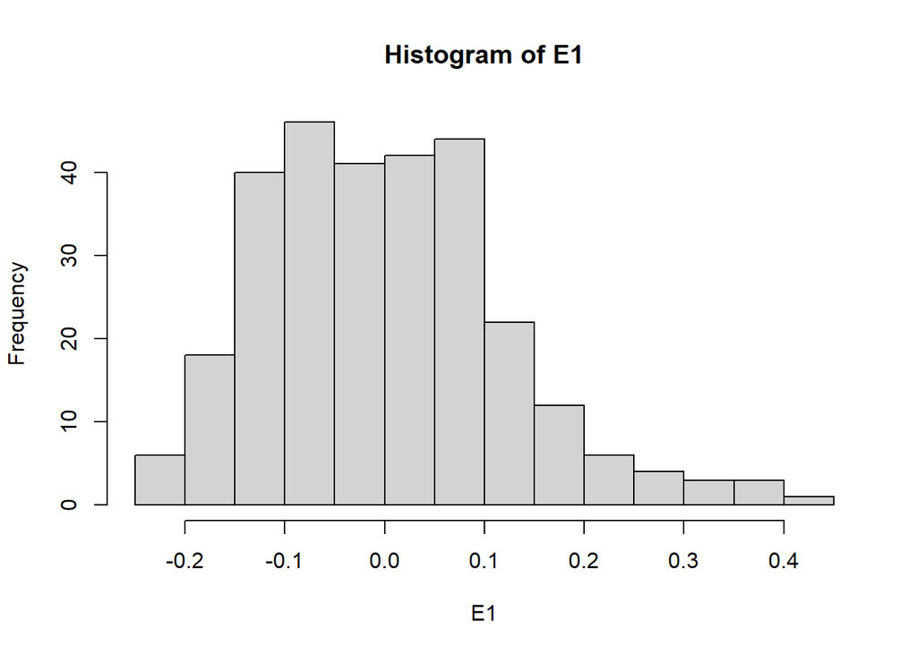

```r
MOD <- lme.parmod

# Calculate model's residual and fitted values
F1 <- fitted(MOD)
E1 <- residuals(MOD, "pearson")

# See residuals as a histogram, look for normal distribution
hist(E1)
```

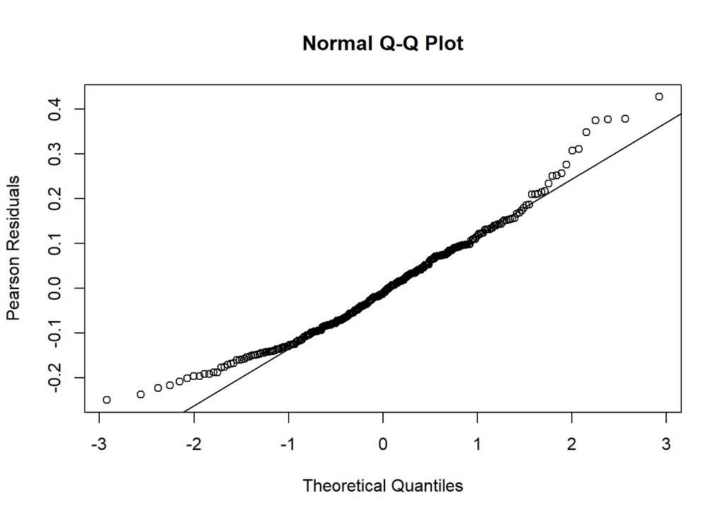

```r
# Graph residuals against a normal distribution, look for all points to be on 1:1 line
#need to call next two lines together
qqnorm(E1, xlab = "Theoretical Quantiles", ylab = "Pearson Residuals")
qqline(E1)
```

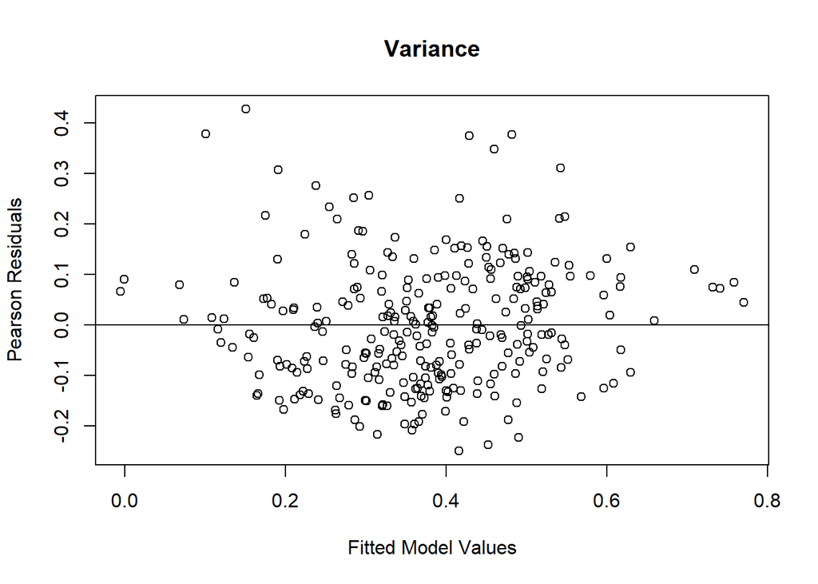

```r
# Graph residuals vs fitted values to inspect homogeneity of variance, look for a random scattering of plots
# run together 2 lines
plot(x=F1, y=E1, xlab="Fitted Model Values", ylab="Pearson Residuals", main = "Variance")
abline(h = 0) # looking for random scatter
```

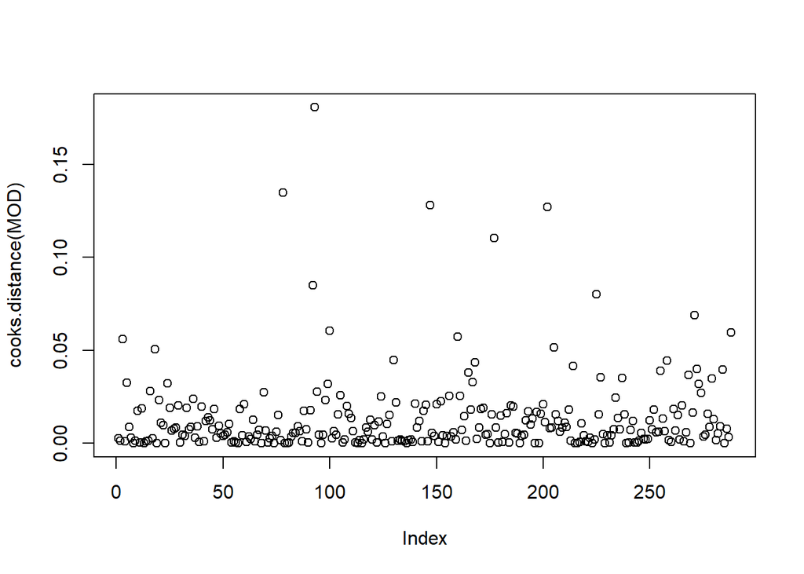

```r
# Check for crazy outliers, look for lines MUCH taller than the rest of data
plot(cooks.distance(MOD))
```

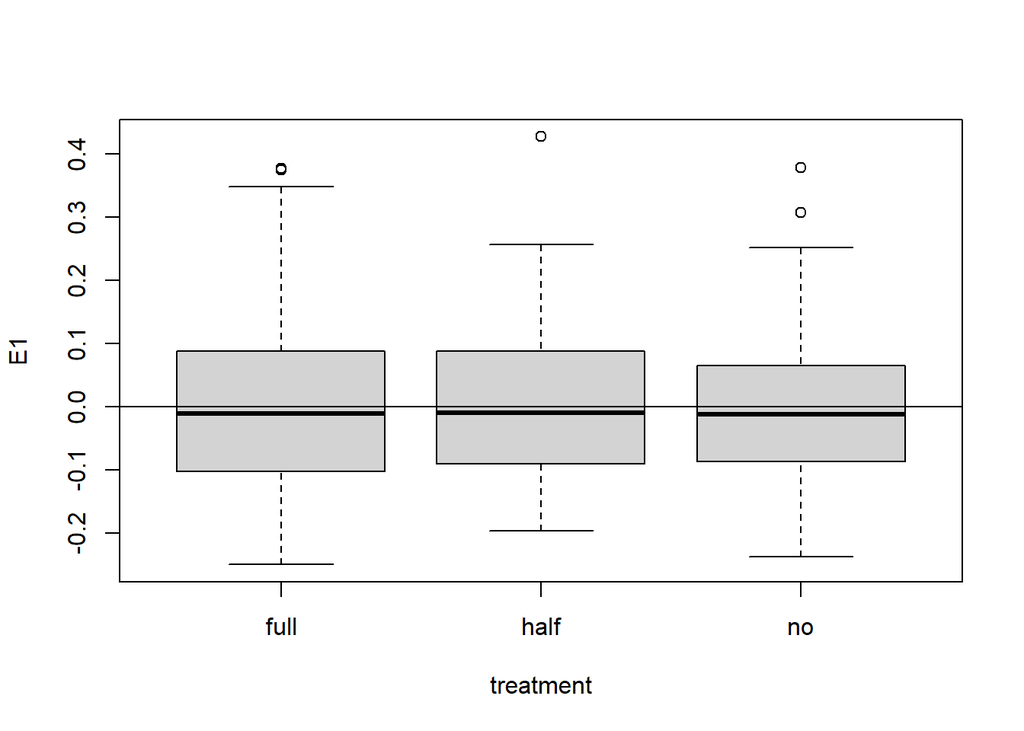

```r
# Plot a box plot for each factor, look for equal variance amount levels along the zero line
# Box plots need to be assessed for every fixed effect (categorical factor) for your model.
# Random effects need the qqline just like normality.
# So, only site and treatment get box plots.
# MAFA cover is a covariate (continuous variable).
boxplot(E1 ~ treatment, data = parmod)
abline(h = 0)
```

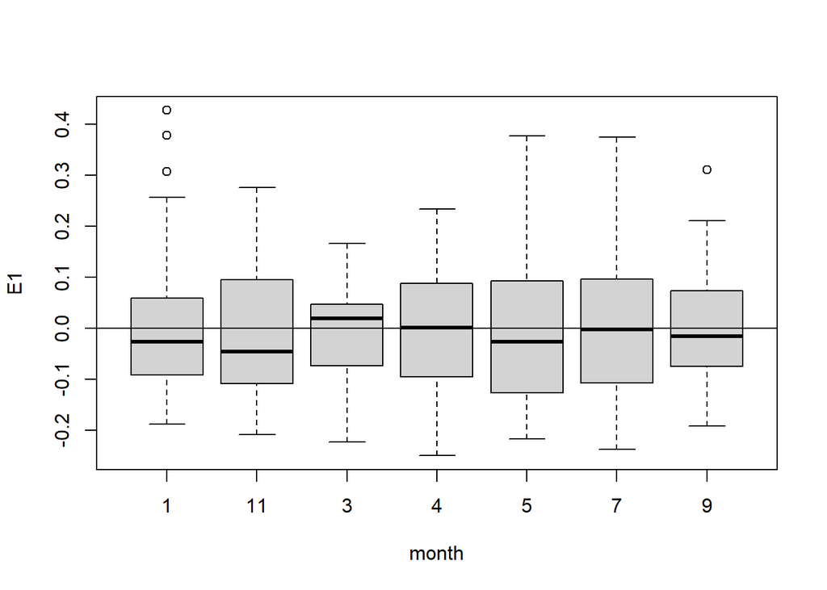

```r
boxplot(E1 ~ month, data = parmod)
abline(h = 0)
```

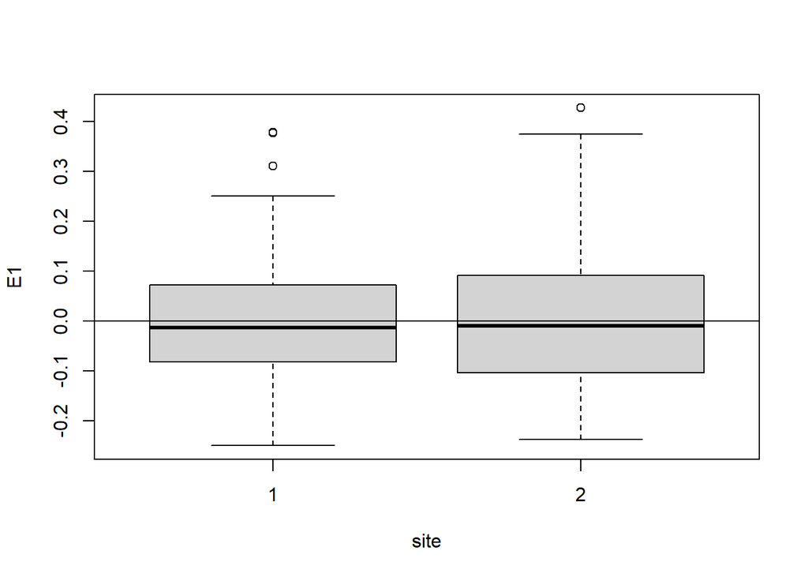

```r
boxplot(E1 ~ site, data = parmod)
abline(h = 0)
```

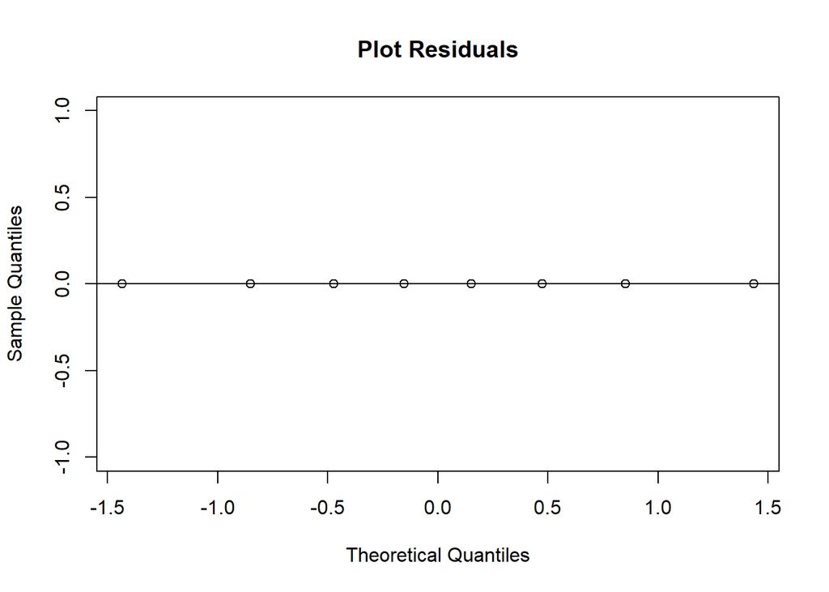

```r
# Plot each random effect in the model - things in the (1|_), look for dots along 1:1 line
qqnorm(ranef(MOD)$date[,1], main = "Plot Residuals")
qqline(ranef(MOD)$date[,1]) # unique dates
```

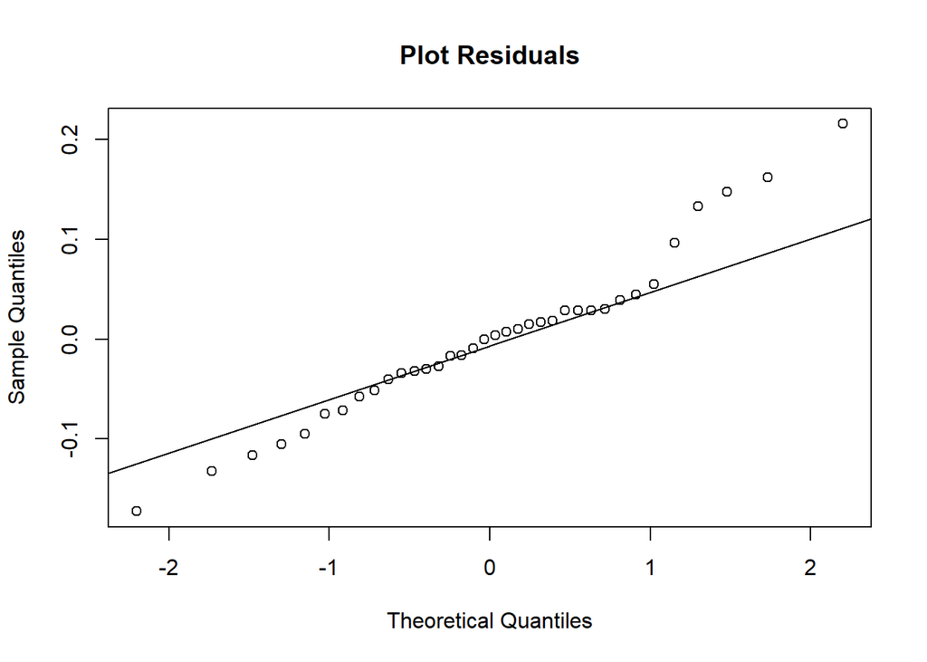

```r
qqnorm(ranef(MOD)$plot_number[,1], main = "Plot Residuals")
qqline(ranef(MOD)$plot_number[,1]) # unique plots
```

```r
#qqnorm(ranef(MOD)$year[,1], main = "Plot Residuals") # year doesn't run becuase only 2 numbers
#qqline(ranef(MOD)$year[,1]) # unique plots
```

3. statistics

```r
# print
print(lme.parmod)
```

```
## Linear mixed model fit by REML ['lmerModLmerTest']
## Formula: normalized_par ~ treatment + mafacover + site + month + (1 |
##     date) + (1 | plot_number) + (1 | year)
##    Data: parmod
## REML criterion at convergence: -240.0224
## Random effects:
##  Groups      Name        Std.Dev.
##  plot_number (Intercept) 9.602e-02
##  date        (Intercept) 0.000e+00
##  year        (Intercept) 2.715e-06
##  Residual                1.306e-01
## Number of obs: 288, groups:  plot_number, 36; date, 8; year, 2
## Fixed Effects:
##   (Intercept)  treatmenthalf    treatmentno      mafacover          site2
##      0.302990      -0.003299      -0.009332      -0.003251       0.033599
##       month11         month3         month4         month5         month7
##      0.073799       0.227356       0.086822       0.198056       0.166201
##        month9
##      0.215059
## optimizer (nloptwrap) convergence code: 0 (OK) ; 0 optimizer warnings; 1 lme4 warnings
```

```r
summary(lme.parmod) # p-values
```

```
## Linear mixed model fit by REML. t-tests use Satterthwaite's method [
## lmerModLmerTest]
## Formula: normalized_par ~ treatment + mafacover + site + month + (1 |
##     date) + (1 | plot_number) + (1 | year)
##    Data: parmod
##
## REML criterion at convergence: -240
##
## Scaled residuals:
##     Min      1Q  Median      3Q     Max
## -1.9062 -0.7163 -0.0830  0.5892  3.2696
##
## Random effects:
##  Groups      Name        Variance  Std.Dev.
##  plot_number (Intercept) 9.220e-03 9.602e-02
##  date        (Intercept) 0.000e+00 0.000e+00
##  year        (Intercept) 7.371e-12 2.715e-06
##  Residual                1.706e-02 1.306e-01
## Number of obs: 288, groups:  plot_number, 36; date, 8; year, 2
##
## Fixed effects:
##                 Estimate Std. Error         df t value Pr(>|t|)
## (Intercept)    3.030e-01  4.799e-02  6.792e+01   6.313 2.40e-08 ***
## treatmenthalf -3.299e-03  4.580e-02  3.465e+01  -0.072 0.942996
## treatmentno   -9.332e-03  4.829e-02  3.874e+01  -0.193 0.847789
## mafacover     -3.251e-03  9.261e-04  1.377e+02  -3.510 0.000606 ***
## site2          3.360e-02  4.016e-02  4.019e+01   0.837 0.407691
## month11        7.380e-02  3.079e-02  2.447e+02   2.397 0.017288 *
## month3         2.274e-01  3.079e-02  2.447e+02   7.384 2.40e-12 ***
## month4         8.682e-02  3.315e-02  2.688e+02   2.619 0.009318 **
## month5         1.981e-01  3.079e-02  2.447e+02   6.432 6.54e-10 ***
## month7         1.662e-01  3.079e-02  2.447e+02   5.398 1.59e-07 ***
## month9         2.151e-01  2.736e-02  2.549e+02   7.859 1.09e-13 ***
## ---
## Signif. codes:  0 '***' 0.001 '**' 0.01 '*' 0.05 '.' 0.1 ' ' 1
##
## Correlation of Fixed Effects:
##             (Intr) trtmnth trtmntn mafcvr site2  mnth11 month3 month4 month5
## treatmnthlf -0.267
## treatmentno -0.182  0.564
## mafacover   -0.522 -0.313  -0.434
## site2       -0.571 -0.146  -0.203   0.467
## month11     -0.321  0.000   0.000   0.000  0.000
## month3      -0.321  0.000   0.000   0.000  0.000  0.500
## month4      -0.491 -0.116  -0.161   0.371  0.173  0.464  0.464
## month5      -0.321  0.000   0.000   0.000  0.000  0.500  0.500  0.464
## month7      -0.321  0.000   0.000   0.000  0.000  0.500  0.500  0.464  0.500
## month9      -0.478 -0.070  -0.097   0.224  0.105  0.563  0.563  0.606  0.563
##             month7
## treatmnthlf
## treatmentno
## mafacover
## site2
## month11
## month3
## month4
## month5
## month7
## month9       0.563
## optimizer (nloptwrap) convergence code: 0 (OK)
## boundary (singular) fit: see help('isSingular')
```

```r
anova(lme.parmod) # fixed level effects, pvalues, etc.
```

```
## Type III Analysis of Variance Table with Satterthwaite's method
##            Sum Sq  Mean Sq NumDF   DenDF F value    Pr(>F)
## treatment 0.00067 0.000336     2  34.513  0.0197 0.9805359
## mafacover 0.21026 0.210258     1 137.703 12.3214 0.0006057 ***
## site      0.01195 0.011947     1  40.192  0.7001 0.4076914
## month     1.77375 0.295624     6 250.588 17.3240 < 2.2e-16 ***
## ---
## Signif. codes:  0 '***' 0.001 '**' 0.01 '*' 0.05 '.' 0.1 ' ' 1
```

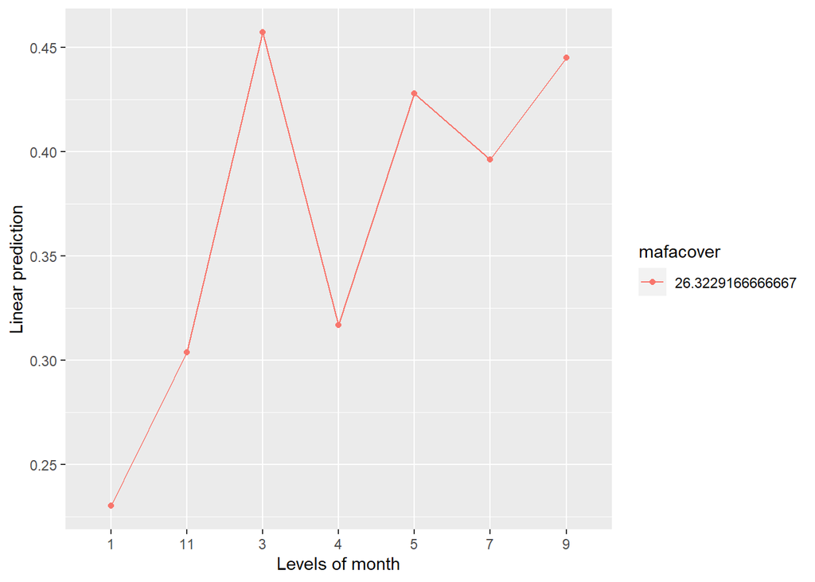

```r
# par is significant by mafa cover and month

# anova(lme.parmod) # fixed level effects, pvalues, etc. <-- WHAT DOES THIS EVEN MEAN???
#Type III Analysis of Variance Table with Satterthwaite's method
#           Sum Sq  Mean Sq NumDF   DenDF F value    Pr(>F)
#treatment 0.00067 0.000336     2  34.513  0.0197 0.9805359
#mafacover 0.21026 0.210258     1 137.703 12.3214 0.0006057 ***
#site      0.01195 0.011947     1  40.192  0.7001 0.4076914
#month     1.77375 0.295624     6 250.588 17.3240 < 2.2e-16 ***

# post-hoc Tukey test
# visualize significant factors from anova(lme.parrmod)

emmip(lme.parmod, mafacover ~ month)
```

```r
# get stats on interactions
emmeans(lme.parmod, list(pairwise ~ mafacover*month), adjust = "tukey") # <--- What do these results mean?
```

[output not shown]

```
## $`emmeans of mafacover, month`
##  mafacover month emmean     SE   df lower.CL upper.CL
##       26.3 1      0.230    NaN 0.00      NaN      NaN
##       26.3 11     0.304    NaN 0.00      NaN      NaN
##       26.3 3      0.457    NaN 0.00      NaN      NaN
##       26.3 4      0.317    NaN 0.00      NaN      NaN
##       26.3 5      0.428    NaN 0.00      NaN      NaN
##       26.3 7      0.396    NaN 0.00      NaN      NaN
##       26.3 9      0.445 0.0508 3.04    0.285    0.606
##
## Results are averaged over the levels of: treatment, site
## Degrees-of-freedom method: kenward-roger
## Confidence level used: 0.95
##
## $`pairwise differences of mafacover, month`
##  1                                                                    estimate
##  mafacover26.3229166666667 month1 - mafacover26.3229166666667 month11  -0.0738
##  mafacover26.3229166666667 month1 - mafacover26.3229166666667 month3   -0.2274
##  mafacover26.3229166666667 month1 - mafacover26.3229166666667 month4   -0.0868
##  mafacover26.3229166666667 month1 - mafacover26.3229166666667 month5   -0.1981
##  mafacover26.3229166666667 month1 - mafacover26.3229166666667 month7   -0.1662
##  mafacover26.3229166666667 month1 - mafacover26.3229166666667 month9   -0.2151
##  mafacover26.3229166666667 month11 - mafacover26.3229166666667 month3  -0.1536
##  mafacover26.3229166666667 month11 - mafacover26.3229166666667 month4  -0.0130
##  mafacover26.3229166666667 month11 - mafacover26.3229166666667 month5  -0.1243
##  mafacover26.3229166666667 month11 - mafacover26.3229166666667 month7  -0.0924
##  mafacover26.3229166666667 month11 - mafacover26.3229166666667 month9  -0.1413
##  mafacover26.3229166666667 month3 - mafacover26.3229166666667 month4    0.1405
##  mafacover26.3229166666667 month3 - mafacover26.3229166666667 month5    0.0293
##  mafacover26.3229166666667 month3 - mafacover26.3229166666667 month7    0.0612
##  mafacover26.3229166666667 month3 - mafacover26.3229166666667 month9    0.0123
##  mafacover26.3229166666667 month4 - mafacover26.3229166666667 month5   -0.1112
##  mafacover26.3229166666667 month4 - mafacover26.3229166666667 month7   -0.0794
##  mafacover26.3229166666667 month4 - mafacover26.3229166666667 month9   -0.1282
##  mafacover26.3229166666667 month5 - mafacover26.3229166666667 month7    0.0319
##  mafacover26.3229166666667 month5 - mafacover26.3229166666667 month9   -0.0170
##  mafacover26.3229166666667 month7 - mafacover26.3229166666667 month9   -0.0489
##      SE df t.ratio p.value
##  0.0418  0  -1.764     NaN
##     NaN  0     NaN     NaN
```

[output cut: 8 more lines]

```
##     NaN  0     NaN     NaN
##     NaN  0     NaN     NaN
##     NaN  0     NaN     NaN
##     NaN  0     NaN     NaN
##     NaN  0     NaN     NaN
##     NaN  0     NaN     NaN
##     NaN  0     NaN     NaN
##     NaN  0     NaN     NaN
##     NaN  0     NaN     NaN
##     NaN  0     NaN     NaN
##     NaN  0     NaN     NaN
##
## Results are averaged over the levels of: treatment, site
## Degrees-of-freedom method: kenward-roger
## P value adjustment: tukey method for comparing a family of 7 estimates
```

```r
# mean, SE: year x month
parmod %>%
  group_by(year, month) %>%
  summarise(MEAN_par=mean(normalized_par, na.rm = TRUE),
            SD = sd(normalized_par, na.rm = TRUE),
            N = length(normalized_par),
            SE = ((sd(normalized_par, na.rm = TRUE))/sqrt(length((normalized_par))))
            )
```

```
## # A tibble: 8 × 6
## # Groups:   year [2]
##   year  month MEAN_par    SD     N     SE
##   <chr> <chr>    <dbl> <dbl> <int>  <dbl>
## 1 2018  4        0.349 0.139    36 0.0231
## 2 2018  9        0.481 0.135    36 0.0224
## 3 2019  1        0.219 0.156    36 0.0260
## 4 2019  11       0.293 0.172    36 0.0286
## 5 2019  3        0.447 0.167    36 0.0279
## 6 2019  5        0.417 0.223    36 0.0371
## 7 2019  7        0.385 0.192    36 0.0320
## 8 2019  9        0.431 0.178    36 0.0296
```

```r
# mean, SE: year x treatment
parmod %>%
  group_by(year, treatment) %>%
  summarise(MEAN_par=mean(normalized_par, na.rm = TRUE),
            SD = sd(normalized_par, na.rm = TRUE),
            N = length(normalized_par),
            SE = ((sd(normalized_par, na.rm = TRUE))/sqrt(length((normalized_par))))
            )
```

```
## # A tibble: 6 × 6
## # Groups:   year [2]
##   year  treatment MEAN_par    SD     N     SE
##   <chr> <chr>        <dbl> <dbl> <int>  <dbl>
## 1 2018  full         0.429 0.171    24 0.0350
## 2 2018  half         0.440 0.133    24 0.0271
## 3 2018  no           0.376 0.145    24 0.0296
## 4 2019  full         0.421 0.222    72 0.0261
## 5 2019  half         0.346 0.195    72 0.0229
## 6 2019  no           0.328 0.165    72 0.0194
```

4. figures

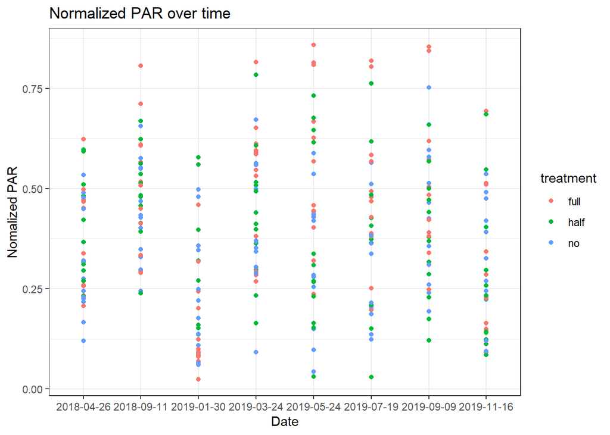

```r
# scatterplot: PAR x date
ggplot(data = parmod, aes(x = date, y = normalized_par)) +
  geom_point(aes(color = treatment)) +
labs(title = "Normalized PAR over time", x = "Date", y = "Nomalized PAR") +
  geom_smooth(method="lm")+
  theme_bw()
```

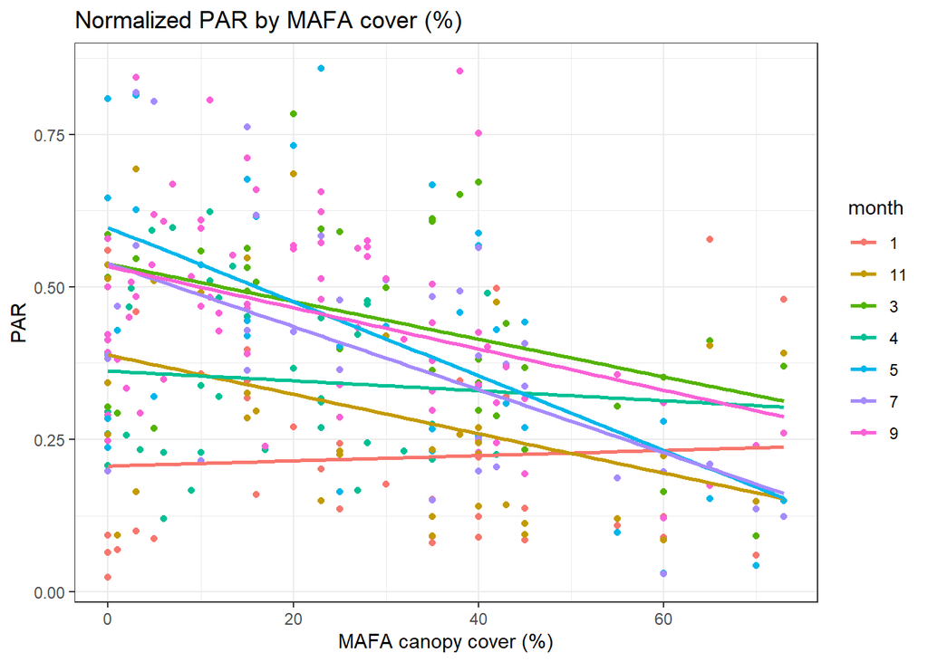

```r
# scatterplot: PAR x mafacover (%) x month
ggplot(data = parmod, aes(x = mafacover, y = normalized_par)) +
  geom_point(aes(color = month)) +
labs(title = "Normalized PAR by MAFA cover (%)", x = "MAFA canopy cover (%)", y = "PAR") +
  geom_smooth(method="lm", se = FALSE, fullrange = TRUE,
              aes(color=month)) +
  theme_bw()
```

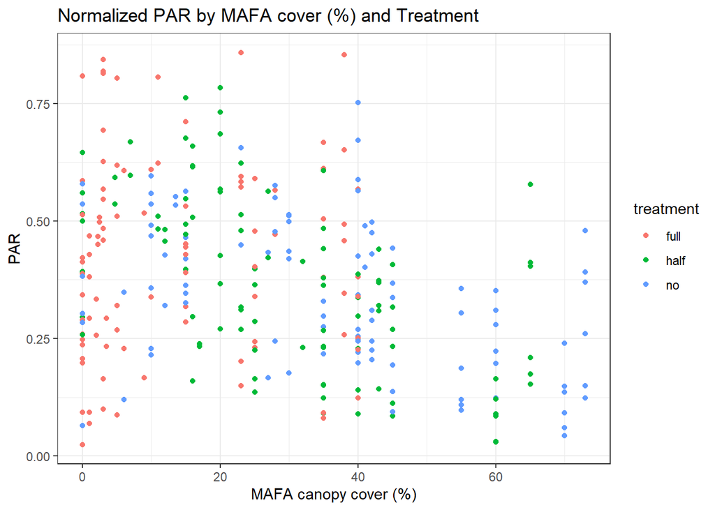

```r
# scatterplot: PAR x mafacover x treatment <-- use treatmentcolor instead of default
ggplot(data = parmod, aes(x = mafacover, y = normalized_par)) +
  geom_point(aes(color = treatment)) +
  labs(title = "Normalized PAR by MAFA cover (%) and Treatment", x = "MAFA canopy cover (%)", y = "PAR") +
  theme_bw()
```

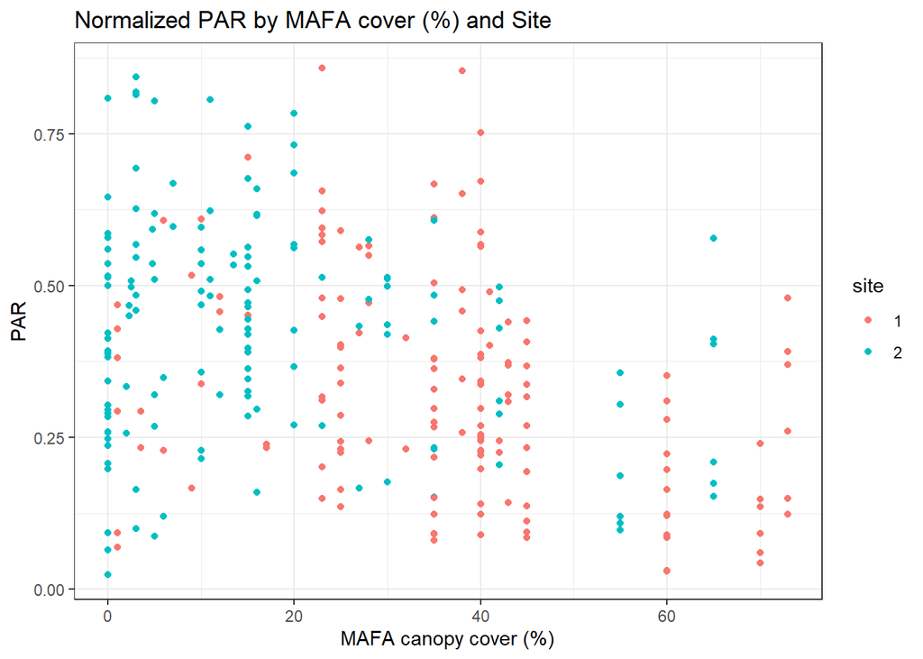

```r
# scatterplot: PAR x mafacover x site <-- make site not continuous & use sitecolor instead of default
ggplot(data = parmod, aes(x = mafacover, y = normalized_par)) +
  geom_point(aes(color = site)) +
  labs(title = "Normalized PAR by MAFA cover (%) and Site", x = "MAFA canopy cover (%)", y = "PAR") +
  theme_bw()
```

```r
#ggplot(crab_data, aes(x = size)) +
#   geom_histogram(binwidth = 1, aes(fill = site)) +
#   scale_fill_manual(values = cal_palette("superbloom")
```

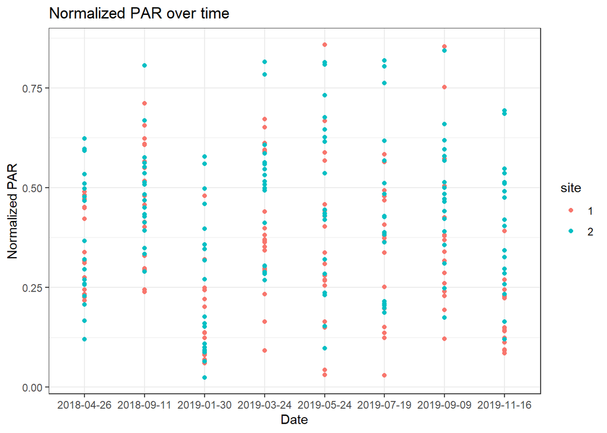

```r
# scatterplot: PAR x month <-- make site not continuous
ggplot(data = parmod, aes(x = date, y = normalized_par)) +
  geom_point(aes(color = site)) +
  labs(title = "Normalized PAR over time", x = "Date", y = "Normalized PAR") +
  theme_bw()
```

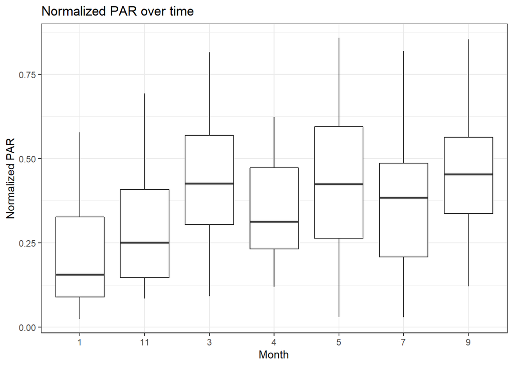

```r
# boxplot: PAR by month <---- KIT - can you make a figure that shows a boxplot of normPAR for each month? <-- need to change YEAR, MONTH, SITE, to character. 3
ggplot(data = parmod,
       aes(x = month, y = normalized_par)) +
  labs(title = "Normalized PAR over time", x = "Month", y = "Normalized PAR") +
  geom_boxplot() +
  theme_bw()
```

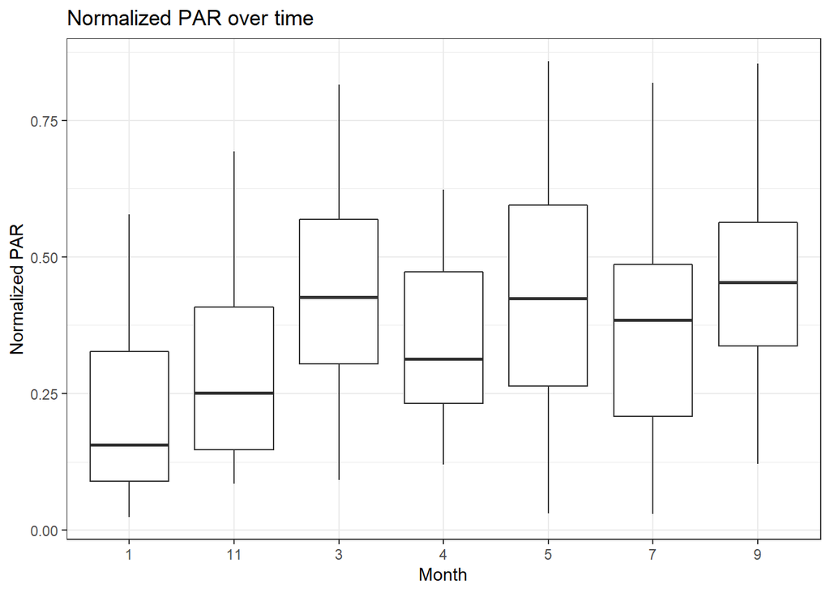

```r
# boxplot of normalized PAR x month
ggplot(data = parmod,
       aes(x = month, y = normalized_par)) +
  labs(title = "Normalized PAR over time", x = "Month", y = "Normalized PAR") +
  geom_boxplot() +
  theme_bw()
```

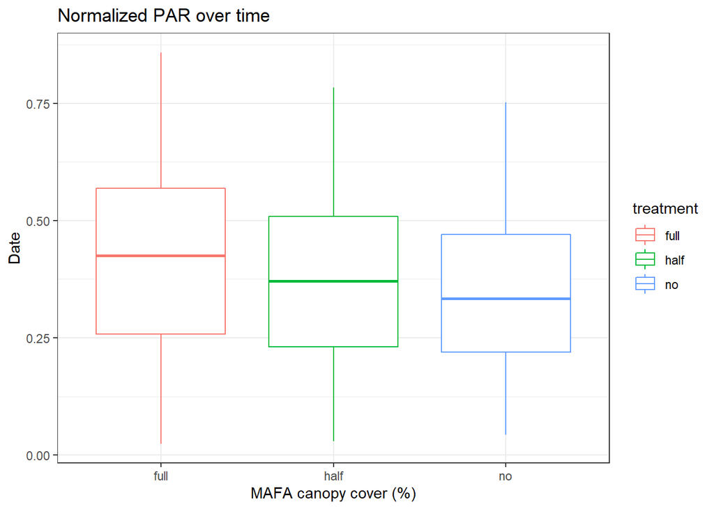

```r
# boxplot: PAR by site x treatment <-- broken and
ggplot(data = parmod, aes(x = treatment, y = normalized_par)) +
  geom_boxplot(aes(color = treatment)) +
  labs(title = "Normalized PAR over time", x = "MAFA canopy cover (%)", y = "Date") +
  theme_bw()
```

## TDR linear mixed-effects model

1. lmer
2. testing the residuals for normality

```r
lme.tdrmod <- lmer(soil_moisture ~ treatment + mafacover + site + year + month + (1|date) +(1|plot_number),
                   data = tdrmod)
```

```
## fixed-effect model matrix is rank deficient so dropping 1 column / coefficient
```

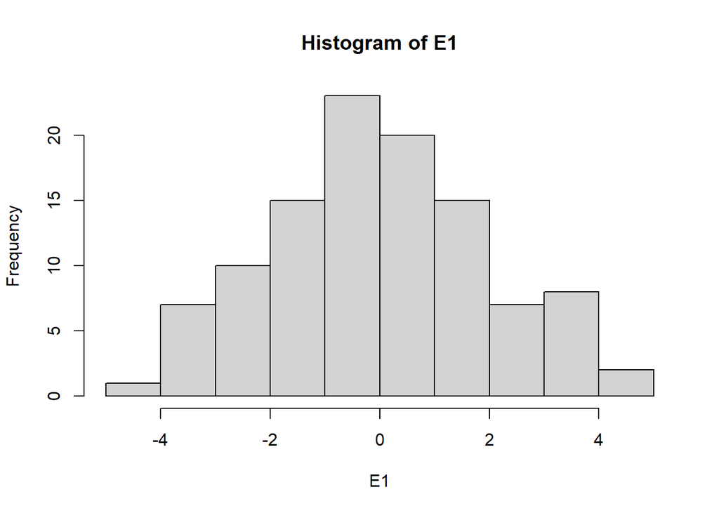

```r
MOD <- lme.tdrmod

# Calculate model's residual and fitted values
F1 <- fitted(MOD)
E1 <- residuals(MOD, "pearson")

# See residuals as a histogram, look for normal distribution
hist(E1)
```

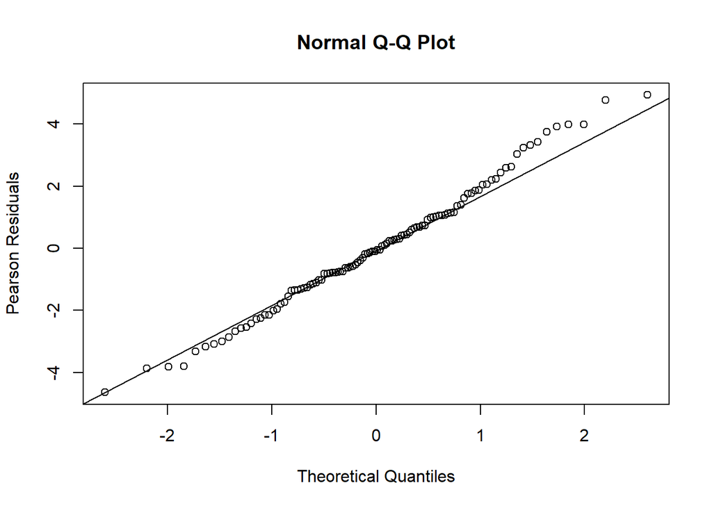

```r
# Graph residuals against a normal distribution, look for all points to be on 1:1 line
#need to call next two lines together
qqnorm(E1, xlab = "Theoretical Quantiles", ylab = "Pearson Residuals")
qqline(E1)
```

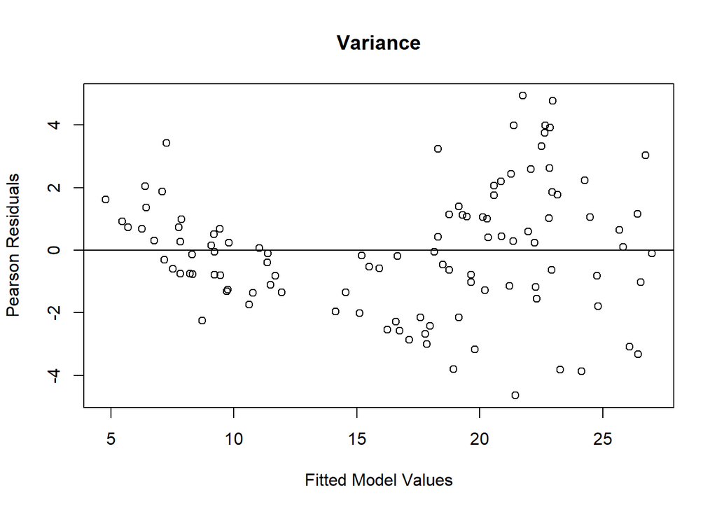

```r
# Graph residuals vs fitted values to inspect homogeneity of variance, look for a random scattering of plots
# run together 2 lines
plot(x=F1, y=E1, xlab="Fitted Model Values", ylab="Pearson Residuals", main = "Variance")
abline(h = 0) # looking for random scatter
```

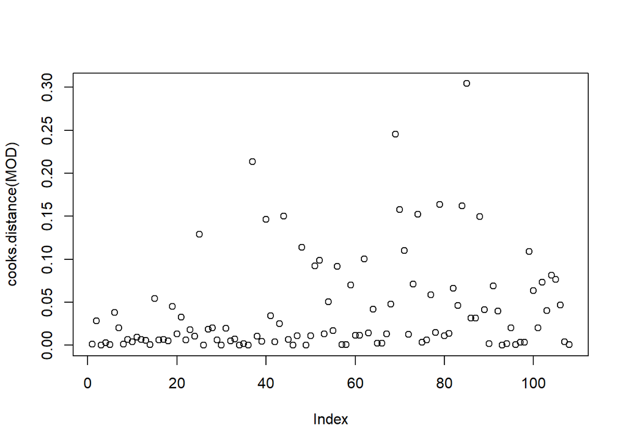

```r
# Check for crazy outliers, look for lines MUCH taller than the rest of data
plot(cooks.distance(MOD))
```

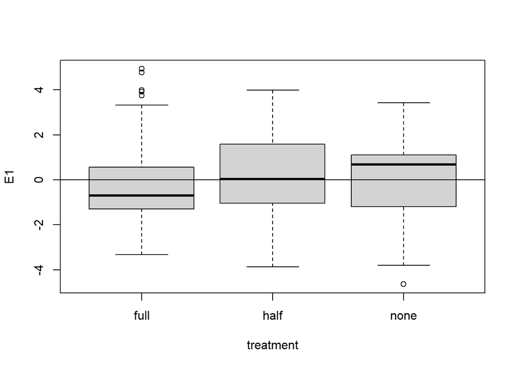

```r
# Plot a box plot for each factor, look for equal variance amount levels along the zero line
# Box plots need to be assessed for every fixed effect (categorical factor) for your model.
# Random effects need the qqline just like normality.
# So, only site and treatment get box plots.
# MAFA cover is a covariate (continuous variable).
boxplot(E1 ~ treatment, data = tdrmod)
abline(h = 0)
```

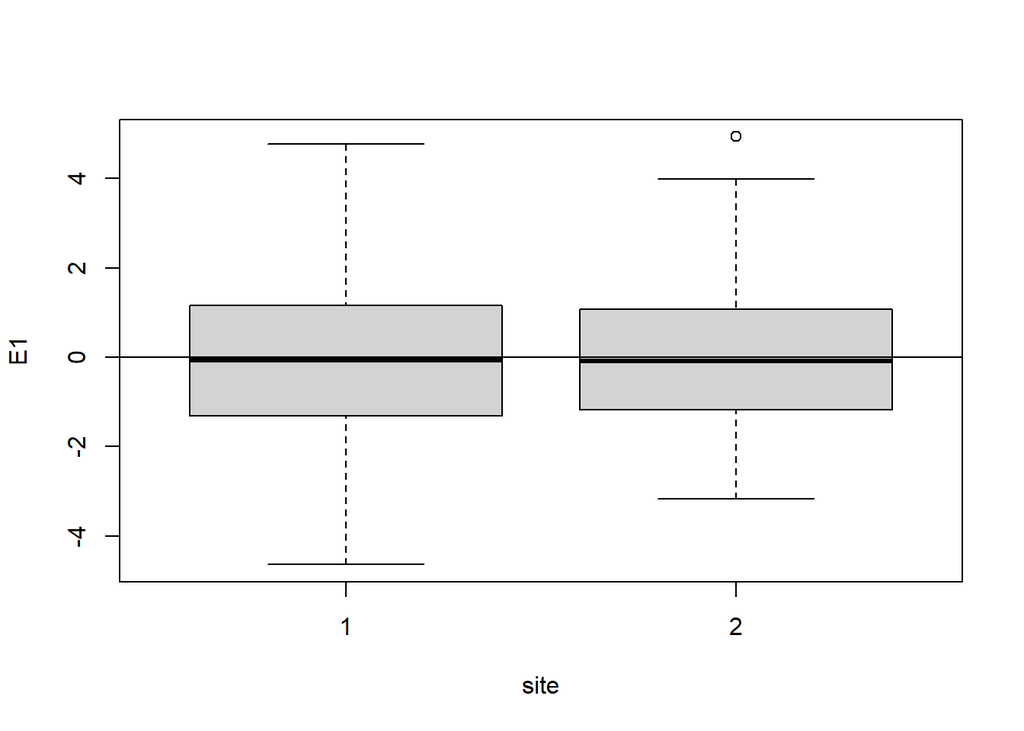

```r
boxplot(E1 ~ site, data = tdrmod)
abline(h = 0)
```

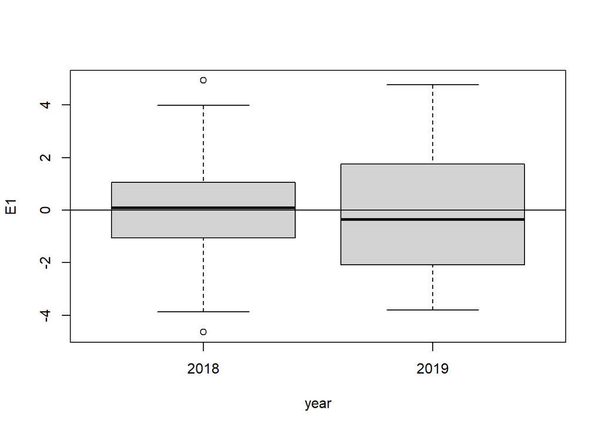

```r
boxplot(E1 ~ year, data = tdrmod)
abline(h = 0)
```

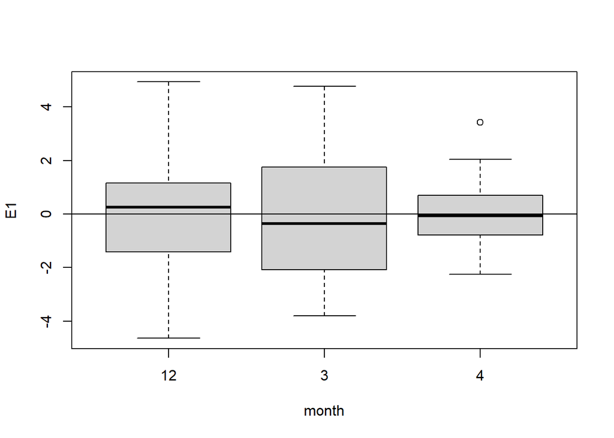

```r
boxplot(E1 ~ month, data = tdrmod)
abline(h = 0)
```

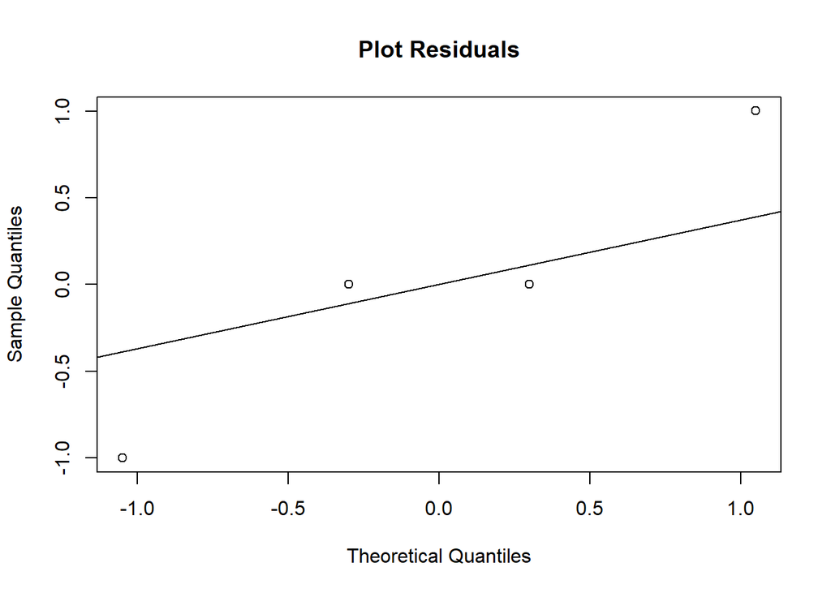

```r
# Plot each random effect in the model, look for dots along 1:1 line
qqnorm(ranef(MOD)$date[,1], main = "Plot Residuals")
qqline(ranef(MOD)$date[,1])
```

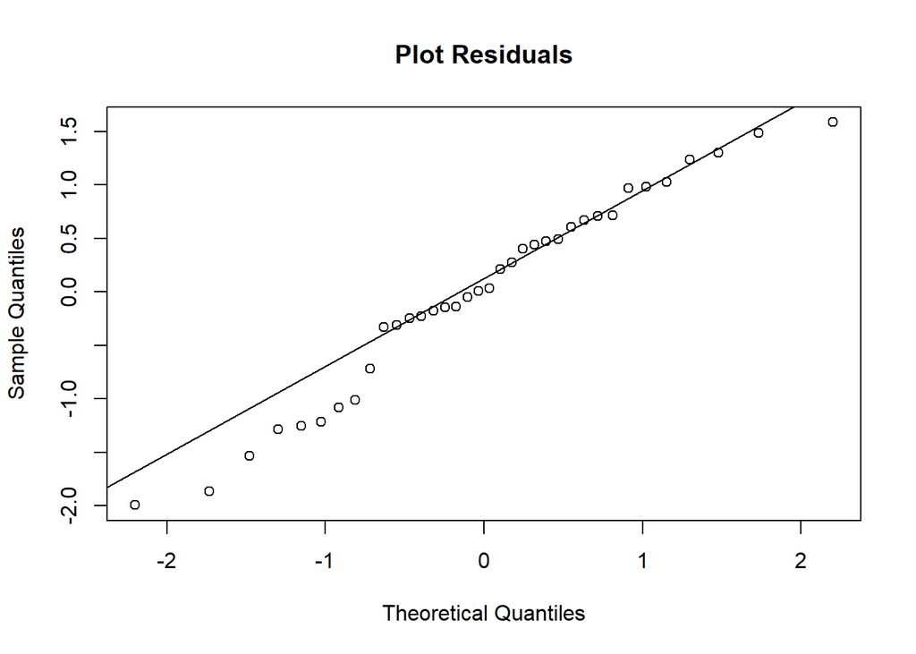

```r
qqnorm(ranef(MOD)$plot_number[,1], main = "Plot Residuals")
qqline(ranef(MOD)$plot_number[,1])
```

3. statistics

```r
# print
print(lme.tdrmod)
```

```
## Linear mixed model fit by REML ['lmerModLmerTest']
## Formula: soil_moisture ~ treatment + mafacover + site + year + month +
##     (1 | date) + (1 | plot_number)
##    Data: tdrmod
## REML criterion at convergence: 505.3515
## Random effects:
##  Groups      Name        Std.Dev.
##  plot_number (Intercept) 1.373
##  date        (Intercept) 1.539
##  Residual                2.249
## Number of obs: 108, groups:  plot_number, 36; date, 4
## Fixed Effects:
##   (Intercept)  treatmenthalf  treatmentnone      mafacover          site2
##      25.69631       -0.87077       -3.17243        0.01871       -3.93896
##      year2019         month4
##      -3.98446      -14.05069
## fit warnings:
## fixed-effect model matrix is rank deficient so dropping 1 column / coefficient
```

```r
summary(lme.tdrmod)
```

```
## Linear mixed model fit by REML. t-tests use Satterthwaite's method [
## lmerModLmerTest]
## Formula: soil_moisture ~ treatment + mafacover + site + year + month +
##     (1 | date) + (1 | plot_number)
##    Data: tdrmod
##
## REML criterion at convergence: 505.4
##
## Scaled residuals:
##      Min       1Q   Median       3Q      Max
## -2.06370 -0.56576 -0.03367  0.48617  2.19509
##
## Random effects:
##  Groups      Name        Variance Std.Dev.
##  plot_number (Intercept) 1.885    1.373
##  date        (Intercept) 2.367    1.539
##  Residual                5.060    2.249
## Number of obs: 108, groups:  plot_number, 36; date, 4
##
## Fixed effects:
##                Estimate Std. Error        df t value Pr(>|t|)
## (Intercept)    25.69631    1.73601   1.15489  14.802  0.02936 *
## treatmenthalf  -0.87077    0.82968  35.77702  -1.050  0.30098
## treatmentnone  -3.17243    0.92201  41.74084  -3.441  0.00133 **
## mafacover       0.01871    0.02544  79.69326   0.735  0.46428
## site2          -3.93896    0.82107  51.47138  -4.797 1.42e-05 ***
## year2019       -3.98446    2.26483   0.84068  -1.759  0.36250
## month4        -14.05069    1.95754   0.83420  -7.178  0.11976
## ---
## Signif. codes:  0 '***' 0.001 '**' 0.01 '*' 0.05 '.' 0.1 ' ' 1
##
## Correlation of Fixed Effects:
##             (Intr) trtmnth trtmntn mafcvr site2  yr2019
## treatmnthlf -0.128
## treatmentnn -0.070  0.590
## mafacover   -0.212 -0.368  -0.548
## site2       -0.282 -0.199  -0.297   0.542
## year2019    -0.606  0.055   0.082  -0.149 -0.081
## month4      -0.738  0.000   0.000   0.000  0.000  0.566
## fit warnings:
## fixed-effect model matrix is rank deficient so dropping 1 column / coefficient
```

```r
anova(lme.tdrmod) # A significant p-value indicates that one or more significant differences exist between group means.
```

```
## Type III Analysis of Variance Table with Satterthwaite's method
##            Sum Sq Mean Sq NumDF  DenDF F value    Pr(>F)
## treatment  67.396  33.698     2 36.094  6.6602  0.003452 **
## mafacover   2.736   2.736     1 79.693  0.5408  0.464279
## site      116.444 116.444     1 51.471 23.0143 1.418e-05 ***
## year       15.660  15.660     1  0.841  3.0951  0.362497
## month     260.672 260.672     1  0.834 51.5197  0.119763
## ---
## Signif. codes:  0 '***' 0.001 '**' 0.01 '*' 0.05 '.' 0.1 ' ' 1
```

```r
# site and treatment are significant. mafacover, year, month are not significant.

# visualize significant factors from anova(lme.tdrmod)
emmip(lme.tdrmod, site ~ treatment)
```

```
## NOTE: A nesting structure was detected in the fitted model:
##     month %in% year
```

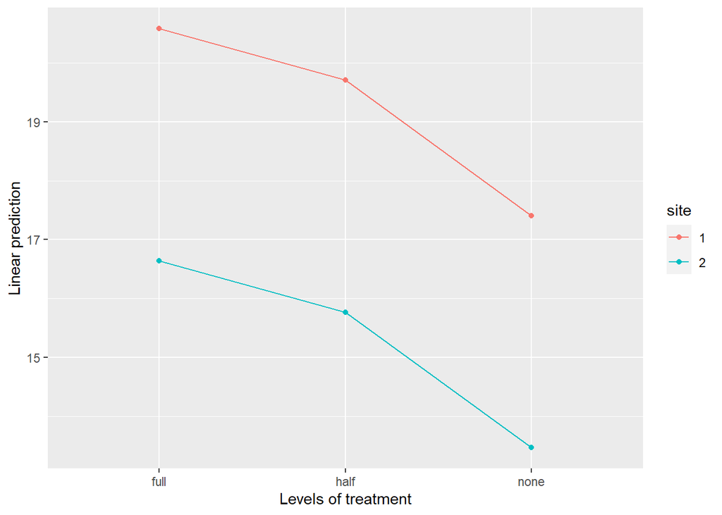

```r
# emmip(lme.tdrmod, month ~ treatment | site)

# get stats on interactions
emmeans(lme.tdrmod, list(pairwise ~ site*treatment), adjust = "tukey")
```

```
## NOTE: A nesting structure was detected in the fitted model:
##     month %in% year
```

```
## $`emmeans of site, treatment`
##  site treatment emmean   SE   df lower.CL upper.CL
##  1    full        20.6 1.12 1.63    14.56     26.6
##  2    full        16.6 1.21 2.15    11.77     21.5
##  1    half        19.7 1.17 1.89    14.40     25.0
##  2    half        15.8 1.13 1.67     9.89     21.7
##  1    none        17.4 1.24 2.37    12.79     22.0
##  2    none        13.5 1.12 1.65     7.51     19.4
##
## Results are averaged over the levels of: month, year
## Degrees-of-freedom method: kenward-roger
## Confidence level used: 0.95
##
## $`pairwise differences of site, treatment`
##  1                       estimate    SE   df t.ratio p.value
##  site1 full - site2 full    3.939 0.875 50.9   4.500  0.0005
##  site1 full - site1 half    0.871 0.833 35.3   1.045  0.8991
##  site1 full - site2 half    4.810 1.076 36.6   4.472  0.0010
##  site1 full - site1 none    3.172 0.930 41.2   3.411  0.0171
##  site1 full - site2 none    7.111 1.063 36.2   6.690  <.0001
##  site2 full - site1 half   -3.068 1.328 47.5  -2.311  0.2101
##  site2 full - site2 half    0.871 0.833 35.3   1.045  0.8991
##  site2 full - site1 none   -0.767 1.460 52.1  -0.525  0.9949
##  site2 full - site2 none    3.172 0.930 41.2   3.411  0.0171
##  site1 half - site2 half    3.939 0.875 50.9   4.500  0.0005
##  site1 half - site1 none    2.302 0.798 33.0   2.883  0.0688
##  site1 half - site2 none    6.241 1.098 37.6   5.684  <.0001
##  site2 half - site1 none   -1.637 1.266 45.0  -1.294  0.7869
##  site2 half - site2 none    2.302 0.798 33.0   2.883  0.0688
##  site1 none - site2 none    3.939 0.875 50.9   4.500  0.0005
##
## Results are averaged over the levels of: month, year
## Degrees-of-freedom method: kenward-roger
## P value adjustment: tukey method for comparing a family of 6 estimates
```

```r
#lsmeans(lme.tdrmod, pairwise~site*treatment, adjust="tukey") # emmeans and lsmeans give the same results

tdrmod %>%
  group_by(year, month) %>%
  summarise(MEAN_soil_moisture=mean(soil_moisture, na.rm = TRUE),
            SD = sd(soil_moisture, na.rm = TRUE),
            N = length(soil_moisture),
            SE = ((sd(soil_moisture, na.rm = TRUE))/sqrt(length((soil_moisture))))
            )
```

```
## # A tibble: 3 × 6
## # Groups:   year [2]
##   year  month MEAN_soil_moisture    SD     N    SE
##   <chr> <chr>              <dbl> <dbl> <int> <dbl>
## 1 2018  12                 22.7   3.40    36 0.567
## 2 2018  4                   8.63  1.50    36 0.250
## 3 2019  3                  18.9   4.59    36 0.766
```

```r
# TDR by Site and Treatment
# tdrmod$site  <- as.factor(tdrmod$site) # to make site a factor
tdrmod_site_treat <- aov(soil_moisture ~ site*treatment, data = tdrmod)
anova(tdrmod_site_treat)
```

```
## Analysis of Variance Table
##
## Response: soil_moisture
##                 Df Sum Sq Mean Sq F value  Pr(>F)
## site             1  344.6  344.57  7.7568 0.00638 **
## treatment        2  154.9   77.45  1.7434 0.18009
## site:treatment   2    4.6    2.29  0.0516 0.94971
## Residuals      102 4531.0   44.42
## ---
## Signif. codes:  0 '***' 0.001 '**' 0.01 '*' 0.05 '.' 0.1 ' ' 1
```

```r
TukeyHSD(tdrmod_site_treat)
```

```
##   Tukey multiple comparisons of means
##     95% family-wise confidence level
##
## Fit: aov(formula = soil_moisture ~ site * treatment, data = tdrmod)
##
## $site
##          diff       lwr       upr     p adj
## 2-1 -3.572377 -6.116555 -1.028198 0.0063802
##
## $treatment
##                 diff       lwr      upr     p adj
## half-full -0.6462963 -4.382655 3.090062 0.9110153
## none-full -2.8011574 -6.537516 0.935201 0.1803794
## none-half -2.1548611 -5.891219 1.581497 0.3595155
##
## $`site:treatment`
##                     diff        lwr         upr     p adj
## 2:full-1:full -4.1518519 -10.604911  2.30120729 0.4272104
## 1:half-1:full -1.0537037  -7.506763  5.39935544 0.9969396
## 2:half-1:full -4.3907407 -10.843800  2.06231840 0.3630396
## 1:none-1:full -3.2629630  -9.716022  3.19009618 0.6847919
## 2:none-1:full -6.4912037 -12.944263 -0.03814456 0.0477765
## 1:half-2:full  3.0981481  -3.354911  9.55120729 0.7302217
## 2:half-2:full -0.2388889  -6.691948  6.21417026 0.9999979
## 1:none-2:full  0.8888889  -5.564170  7.34194803 0.9986430
## 2:none-2:full -2.3393519  -8.792411  4.11370729 0.8985235
## 2:half-1:half -3.3370370  -9.790096  3.11602211 0.6637467
## 1:none-1:half -2.2092593  -8.662318  4.24379989 0.9187462
## 2:none-1:half -5.4375000 -11.890559  1.01555914 0.1500570
## 1:none-2:half  1.1277778  -5.325281  7.58083692 0.9957812
## 2:none-2:half -2.1004630  -8.553522  4.35259618 0.9335708
## 2:none-1:none -3.2282407  -9.681300  3.22481840 0.6945361
```

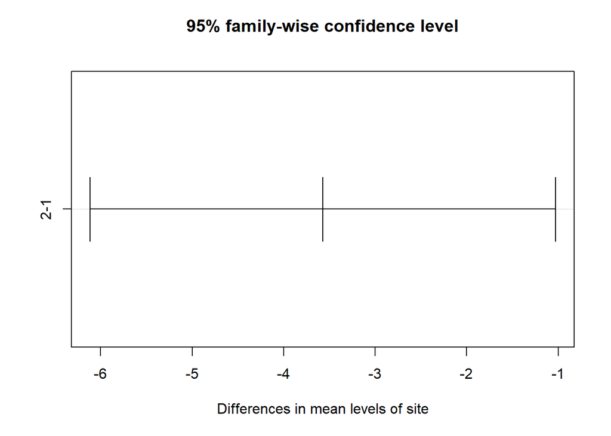

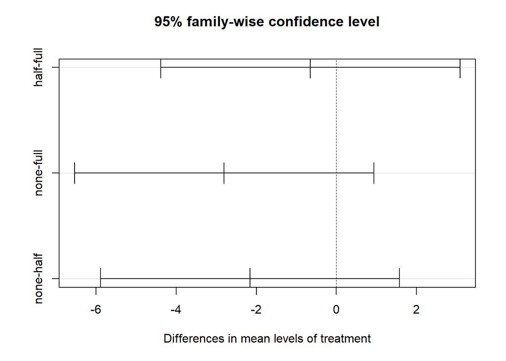

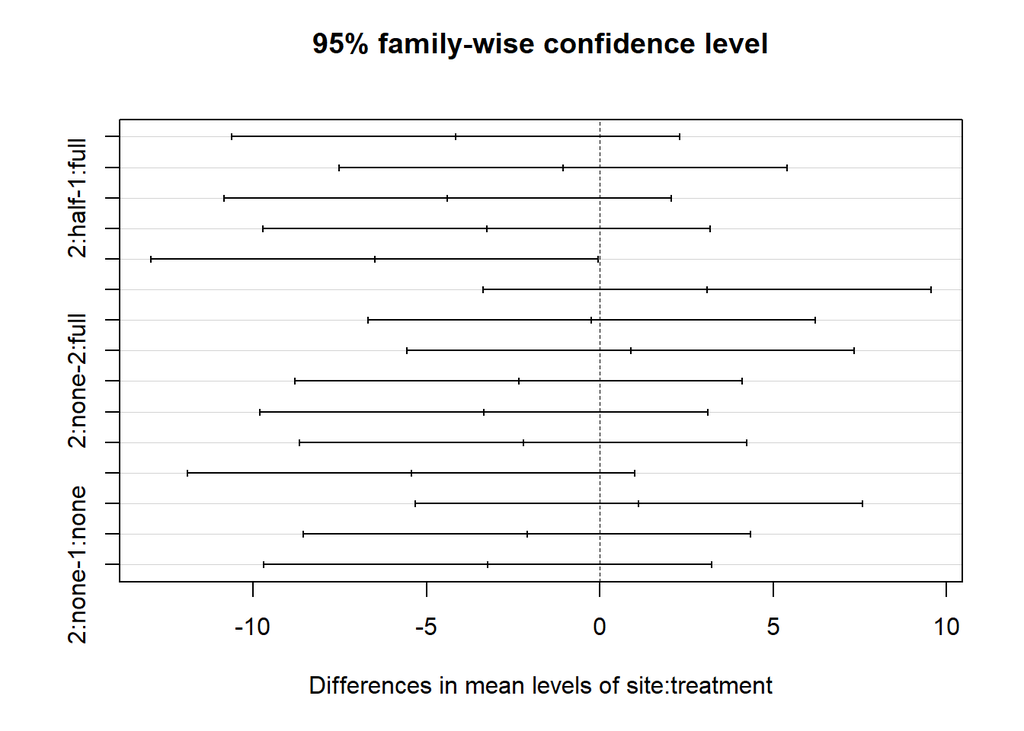

```r
plot(TukeyHSD(tdrmod_site_treat))
```

```r
# 2:none-1:full -6.4912037 -12.944263 -0.03814456 0.0477765

# TDR by Site <-- why does this say site is sig when it wasn't before?
tdrmod_site <- aov(soil_moisture ~ site, data = tdrmod)
anova(tdrmod_site)
```

```
## Analysis of Variance Table
##
## Response: soil_moisture
##            Df Sum Sq Mean Sq F value   Pr(>F)
## site        1  344.6  344.57  7.7869 0.006242 **
## Residuals 106 4690.5   44.25
## ---
## Signif. codes:  0 '***' 0.001 '**' 0.01 '*' 0.05 '.' 0.1 ' ' 1
```

```r
# site        1  344.6  344.57  7.7869 0.006242 **

tdrmod_treat <- aov(soil_moisture ~ treatment, data = tdrmod)
anova(tdrmod_treat)
```

```
## Analysis of Variance Table
##
## Response: soil_moisture
##            Df Sum Sq Mean Sq F value Pr(>F)
## treatment   2  154.9  77.446  1.6663 0.1939
## Residuals 105 4880.2  46.478
```

```r
# treatment   2  154.9  77.446  1.6663 0.1939

# For TDR and nn cover, the significant plots may explain results we see later, but the fact that there are 2-3 plots that are significantly different from each other doesn't tell us the sites or treatments are significantly different from each other.
```

4. figures

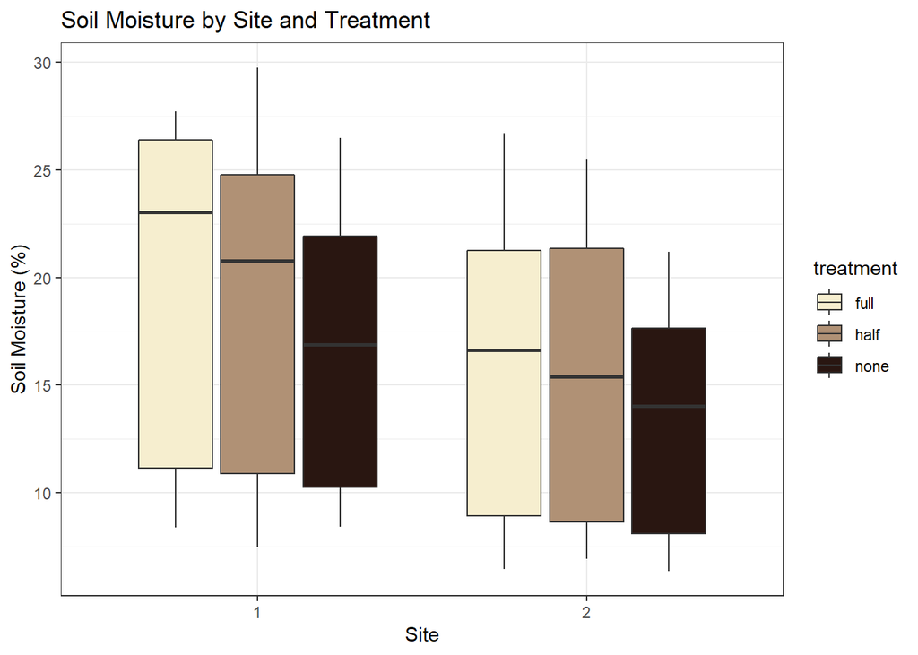

```r
# boxplot: TDR by site by treatment
ggplot(data = tdrmod, aes(x = site, y = soil_moisture)) +
  geom_boxplot(aes(fill = treatment)) +
  scale_fill_manual(values = c('#F6EECF', '#B09175', '#291611')) +
  labs(title = "Soil Moisture by Site and Treatment", x = "Site", y = "Soil Moisture (%)") +
  theme_bw()
```

[figure not shown]

```r
# scatterplot: tdr x mafacover
ggplot(data = tdrmod, aes(x = mafacover, y = soil_moisture)) +
  geom_point(aes(color = site)) +
  scale_color_manual(values=c(sitecolors)) +
  labs(title = "Soil Moisture by Site and Treatment", x = "Site", y = "Soil Moisture (%)") +
  geom_smooth(method="lm")+
  theme_bw()
```

## Non-native cover linear mixed-effects model

1. lmer
2. testing the residuals for normality

```r
#need to convert df to a tibble
#as_tibble(nnmod)
#print(nn)
#names(nnmod)
#print(nnmod)
#str(nnmod)
lme.nnmod <- lmer(nncover ~ treatment + mafacover + site + year + (1|date) + (1|plot_number), # no month column, year = month
                   data = nnmod)
```

```
## boundary (singular) fit: see help('isSingular')
```

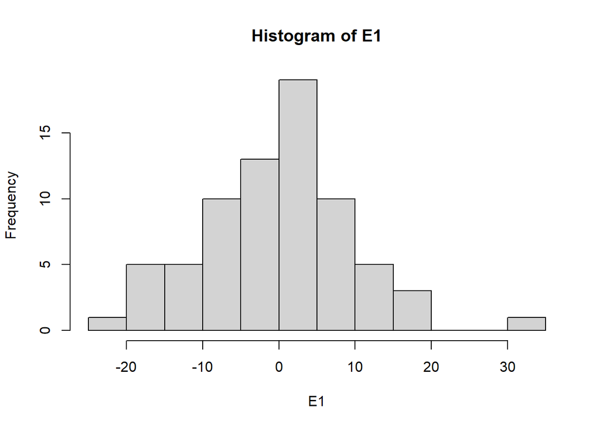

```r
MOD <- lme.nnmod

# Calculate model's residual and fitted values
F1 <- fitted(MOD)
E1 <- residuals(MOD, "pearson")

# See residuals as a histogram, look for normal distribution
hist(E1)
```

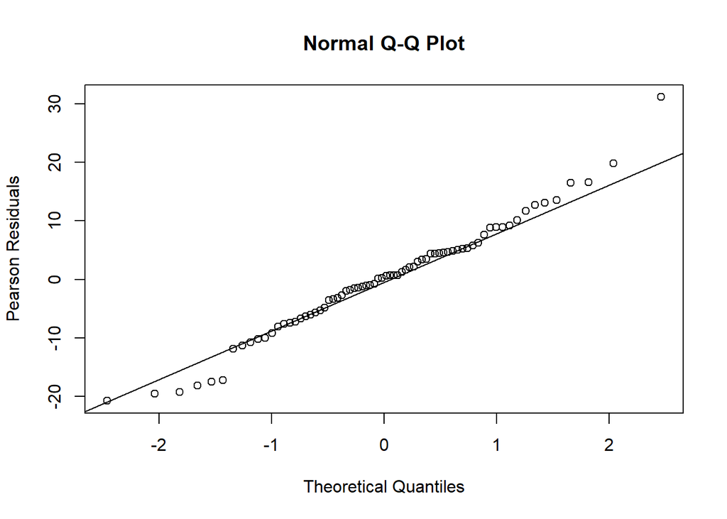

```r
# Graph residuals against a normal distribution, look for all points to be on 1:1 line
#need to call next two lines together
qqnorm(E1, xlab = "Theoretical Quantiles", ylab = "Pearson Residuals")
qqline(E1)
```

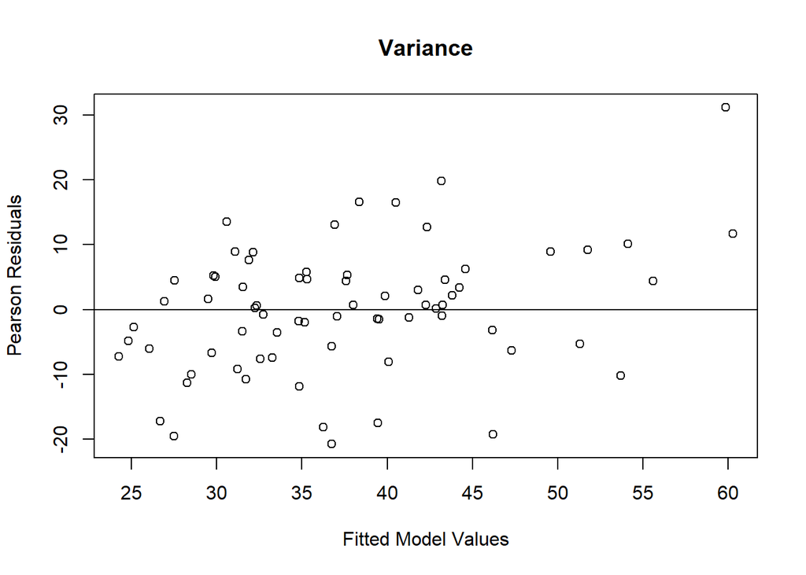

```r
# Graph residuals vs fitted values to inspect homogeneity of variance, look for a random scattering of plots
# run together 2 lines
plot(x=F1, y=E1, xlab="Fitted Model Values", ylab="Pearson Residuals", main = "Variance")
abline(h = 0) # looking for random scatter
```

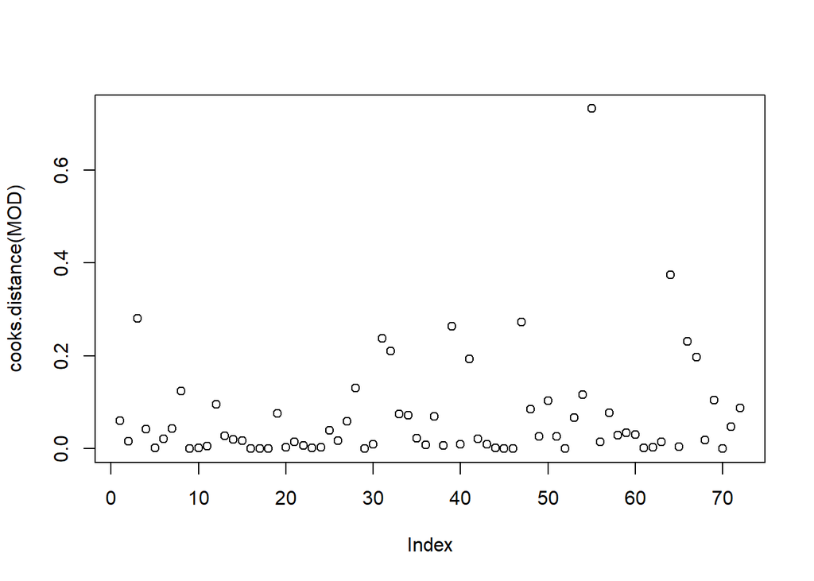

```r
# Check for crazy outliers, look for lines MUCH taller than the rest of data
plot(cooks.distance(MOD))
```

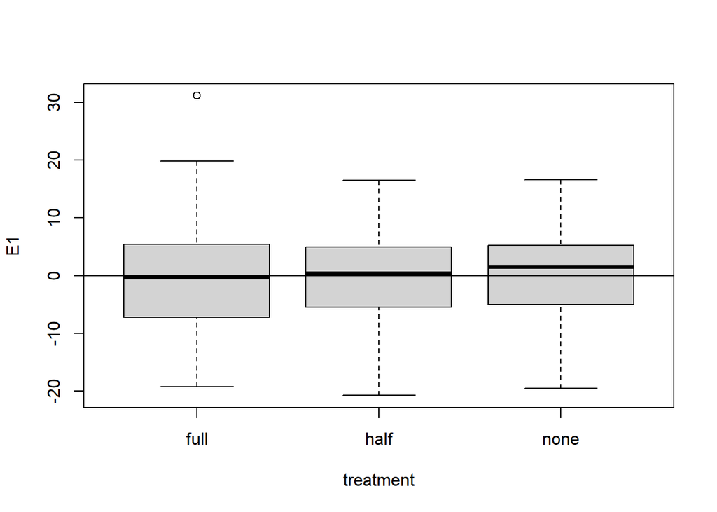

```r
# Plot a box plot for each factor, look for equal variance amount levels along the zero line
# Box plots need to be assessed for every fixed effect (categorical factor) for your model.
# Random effects need the qqline just like normality.
# So, only site and treatment get box plots.
# MAFA cover is a covariate (continuous variable).
boxplot(E1 ~ treatment, data = nnmod)
abline(h = 0)
```

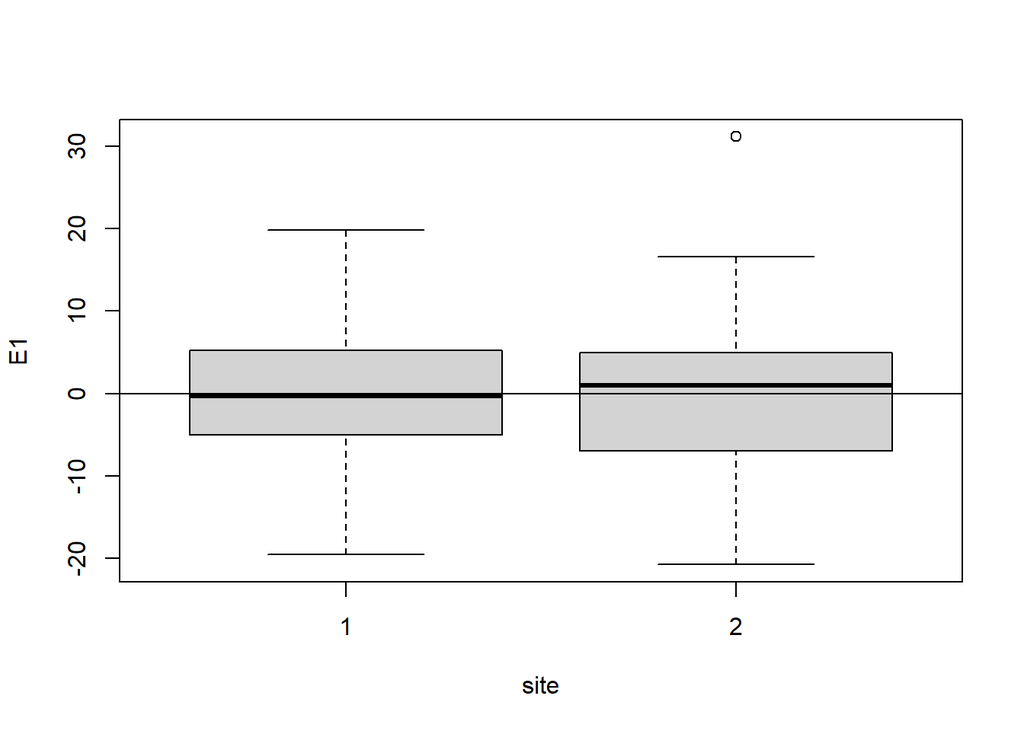

```r
boxplot(E1 ~ site, data = nnmod)
abline(h = 0)
```

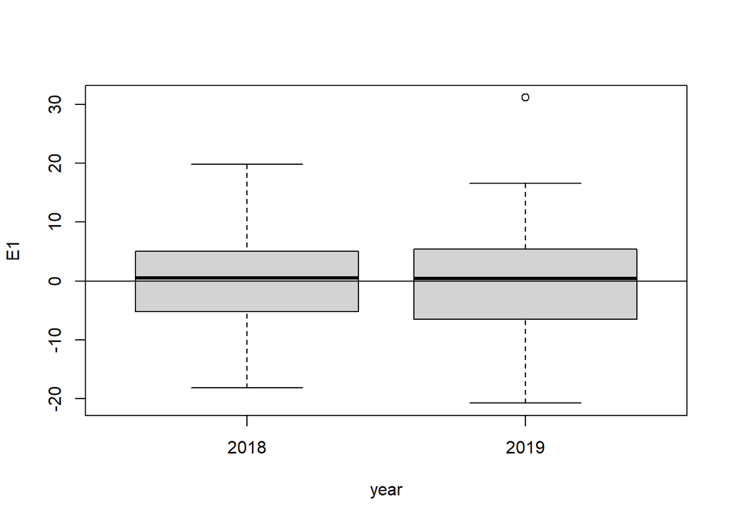

```r
boxplot(E1 ~ year, data = nnmod)
abline(h = 0)
```

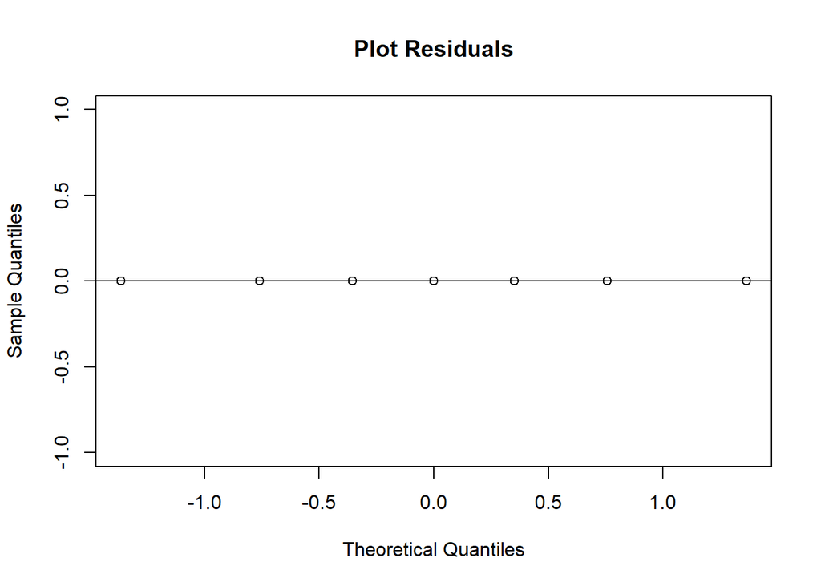

```r
# Plot each random effect in the model, look for dots along 1:1 line
qqnorm(ranef(MOD)$date[,1], main = "Plot Residuals")
qqline(ranef(MOD)$date[,1])
```

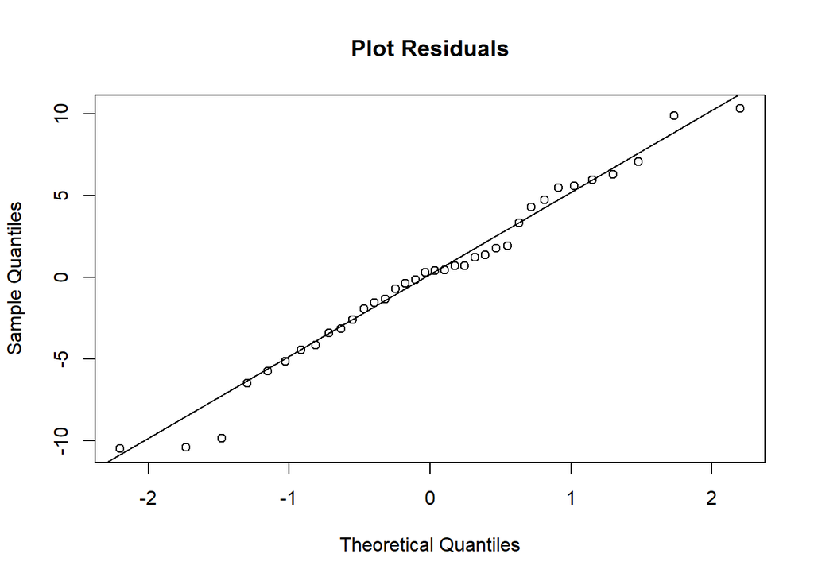

```r
qqnorm(ranef(MOD)$plot_number[,1], main = "Plot Residuals")
qqline(ranef(MOD)$plot_number[,1])
```

3. statistics

```r
# print
print(lme.nnmod)
```

```
## Linear mixed model fit by REML ['lmerModLmerTest']
## Formula: nncover ~ treatment + mafacover + site + year + (1 | date) +
##     (1 | plot_number)
##    Data: nnmod
## REML criterion at convergence: 554.4523
## Random effects:
##  Groups      Name        Std.Dev.
##  plot_number (Intercept)  7.864
##  date        (Intercept)  0.000
##  Residual                11.443
## Number of obs: 72, groups:  plot_number, 36; date, 7
## Fixed Effects:
##   (Intercept)  treatmenthalf  treatmentnone      mafacover          site2
##       44.9303        -9.7929        -4.1434        -0.2244        -1.1405
##      year2019
##        6.1591
## optimizer (nloptwrap) convergence code: 0 (OK) ; 0 optimizer warnings; 1 lme4 warnings
```

```r
summary(lme.nnmod)
```

```
## Linear mixed model fit by REML. t-tests use Satterthwaite's method [
## lmerModLmerTest]
## Formula: nncover ~ treatment + mafacover + site + year + (1 | date) +
##     (1 | plot_number)
##    Data: nnmod
##
## REML criterion at convergence: 554.5
##
## Scaled residuals:
##      Min       1Q   Median       3Q      Max
## -1.81269 -0.53433  0.03835  0.44546  2.72224
##
## Random effects:
##  Groups      Name        Variance Std.Dev.
##  plot_number (Intercept)  61.85    7.864
##  date        (Intercept)   0.00    0.000
##  Residual                130.94   11.443
## Number of obs: 72, groups:  plot_number, 36; date, 7
##
## Fixed effects:
##               Estimate Std. Error      df t value Pr(>|t|)
## (Intercept)    44.9303     4.4321 43.5515  10.138 4.92e-13 ***
## treatmenthalf  -9.7929     4.9691 34.9540  -1.971   0.0567 .
## treatmentnone  -4.1434     5.4522 39.3004  -0.760   0.4518
## mafacover      -0.2244     0.1391 62.2760  -1.613   0.1117
## site2          -1.1405     4.4980 39.7610  -0.254   0.8011
## year2019        6.1591     3.2678 49.5824   1.885   0.0653 .
## ---
## Signif. codes:  0 '***' 0.001 '**' 0.01 '*' 0.05 '.' 0.1 ' ' 1
##
## Correlation of Fixed Effects:
##             (Intr) trtmnth trtmntn mafcvr site2
## treatmnthlf -0.320
## treatmentnn -0.208  0.592
## mafacover   -0.433 -0.375  -0.535
## site2       -0.592 -0.206  -0.293   0.548
## year2019    -0.007  0.212   0.302  -0.565 -0.310
## optimizer (nloptwrap) convergence code: 0 (OK)
## boundary (singular) fit: see help('isSingular')
```

```r
anova(lme.nnmod) # A significant p-value indicates that one or more significant differences exist between group means.
```

```
## Type III Analysis of Variance Table with Satterthwaite's method
##           Sum Sq Mean Sq NumDF  DenDF F value  Pr(>F)
## treatment 542.01  271.01     2 34.887  2.0696 0.14145
## mafacover 340.88  340.88     1 62.276  2.6033 0.11170
## site        8.42    8.42     1 39.761  0.0643 0.80114
## year      465.19  465.19     1 49.582  3.5525 0.06532 .
## ---
## Signif. codes:  0 '***' 0.001 '**' 0.01 '*' 0.05 '.' 0.1 ' ' 1
```

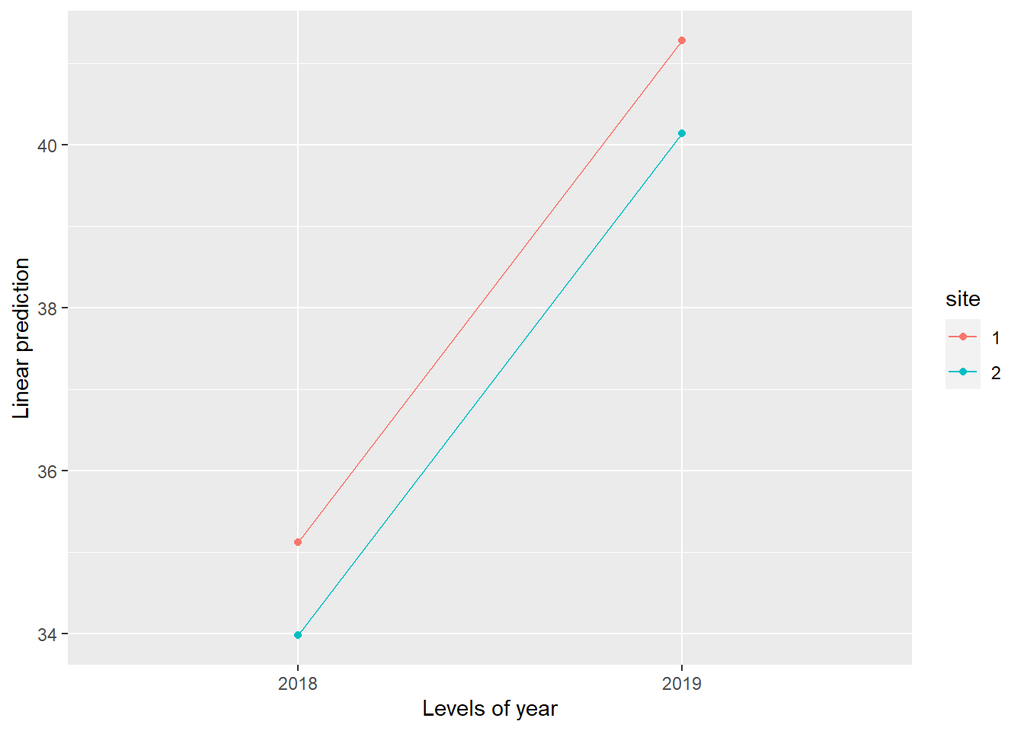

```r
# non-native cover is not correlated with mafa cover, treatment, site, or year.
# year may be ecologically interesting (p = 0.065)

# visualize significant factors from anova(lme.tdrmod)
emmip(lme.nnmod, site ~ year)
```

```r
# emmip(lme.tdrmod, month ~ treatment | site)

# convert from character to number
# nnmod$year <- as.numeric(nnmod$year)
# nnmod$site <- as.numeric(nnmod$site)

# convert from number to character
#nnmod$year <- as.character(nnmod$year)
#nnmod$site <- as.character(nnmod$site)
#nnmod$treatment <- as.character(nnmod$treatment)

# get stats on interactions
emmeans(lme.tdrmod, pairwise~year, adjust="tukey")
```

```
## NOTE: A nesting structure was detected in the fitted model:
##     month %in% year
```

```
## $emmeans
##  year emmean   SE   df lower.CL upper.CL
##  2018   15.7 1.01 0.95      1.2     30.3
##  2019   18.8 1.62 0.87    -10.5     48.1
##
## Results are averaged over the levels of: treatment, site, month
## Degrees-of-freedom method: kenward-roger
## Confidence level used: 0.95
##
## $contrasts
##  contrast            estimate   SE   df t.ratio p.value
##  year2018 - year2019    -3.04 1.89 0.87  -1.606  0.3811
##
## Results are averaged over the levels of: treatment, site, month
## Degrees-of-freedom method: kenward-roger
```

```r
# year is NOT significant p=0.3811

#lsmeans(lme.tdrmod, pairwise~site*treatment, adjust="tukey") # emmeans and lsmeans give the same results

nnmod %>%
  group_by(year, site, treatment) %>%
  summarise(mean_nncover=mean(nncover, na.rm = TRUE),
            sd_nncover = sd(nncover, na.rm = TRUE),
            N = length(nncover),
            SE_nncover=((sd(nncover, na.rm = TRUE))/sqrt(length((nncover))))
            )
```

```
## # A tibble: 12 × 7
## # Groups:   year, site [4]
##    year  site  treatment mean_nncover sd_nncover     N SE_nncover
##    <chr> <chr> <chr>            <dbl>      <dbl> <int>      <dbl>
##  1 2018  1     full              44.0      15.2      6       6.21
##  2 2018  1     half              35.2      10.0      6       4.08
##  3 2018  1     none              30.6       8.65     6       3.53
##  4 2018  2     full              45.0      14.4      6       5.86
##  5 2018  2     half              28.7      13.0      6       5.30
##  6 2018  2     none              32.8      10.2      6       4.16
##  7 2019  1     full              37.3      10.6      6       4.31
##  8 2019  1     half              36.7      12.5      6       5.12
##  9 2019  1     none              33.5      16.2      6       6.61
## 10 2019  2     full              53        26.1      6      10.6
## 11 2019  2     half              27.7      10.6      6       4.32
## 12 2019  2     none              47.2       8.98     6       3.66
```

```r
# non-native cover by treatment
nnmod_treat <- aov(nncover ~ treatment, data = nnmod)
anova(nnmod_treat)
```

```
## Analysis of Variance Table
##
## Response: nncover
##           Df  Sum Sq Mean Sq F value   Pr(>F)
## treatment  2  2061.8 1030.92  5.2387 0.007618 **
## Residuals 69 13578.3  196.79
## ---
## Signif. codes:  0 '***' 0.001 '**' 0.01 '*' 0.05 '.' 0.1 ' ' 1
```

```r
TukeyHSD(nnmod_treat)
```

```
##   Tukey multiple comparisons of means
##     95% family-wise confidence level
##
## Fit: aov(formula = nncover ~ treatment, data = nnmod)
##
## $treatment
##                 diff        lwr        upr     p adj
## half-full -12.799167 -22.499110 -3.0992229 0.0065326
## none-full  -8.849167 -18.549110  0.8507771 0.0808732
## none-half   3.950000  -5.749944 13.6499437 0.5947782
```

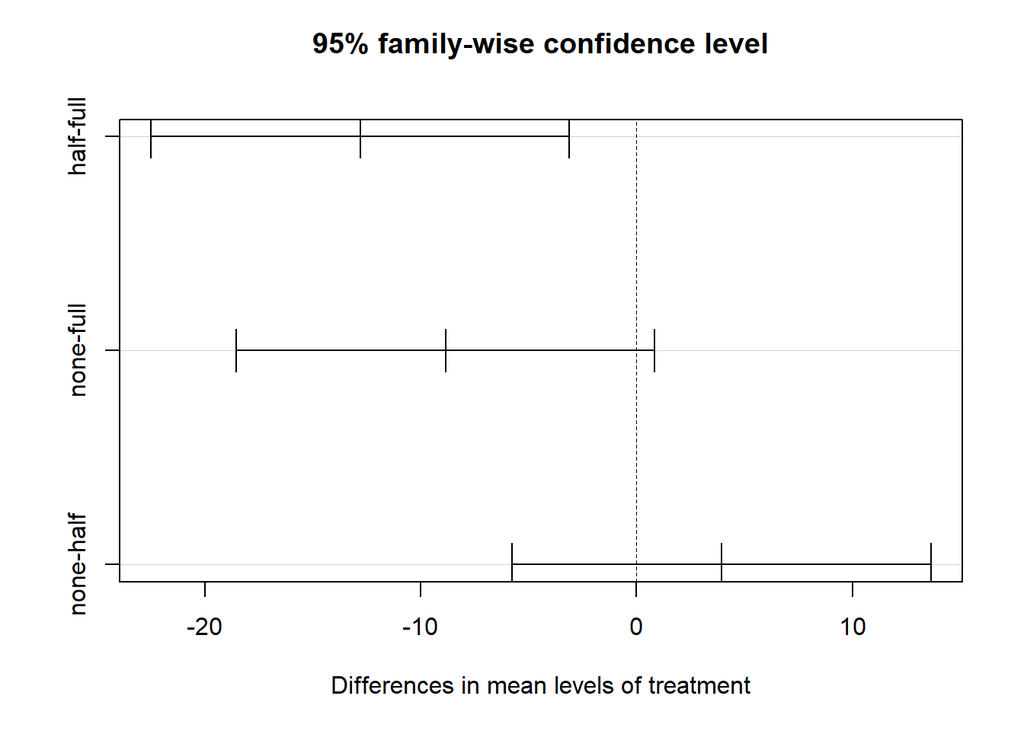

```r
plot(TukeyHSD(nnmod_treat))
```

```r
# non-native cover by treatment and site
nnmod_treat_site <- aov(nncover ~ treatment*site, data = nnmod)
anova(nnmod_treat_site)
```

```
## Analysis of Variance Table
##
## Response: nncover
##                Df  Sum Sq Mean Sq F value   Pr(>F)
## treatment       2  2061.8 1030.92  5.4772 0.006299 **
## site            1   145.2  145.15  0.7712 0.383036
## treatment:site  2  1010.6  505.32  2.6847 0.075691 .
## Residuals      66 12422.5  188.22
## ---
## Signif. codes:  0 '***' 0.001 '**' 0.01 '*' 0.05 '.' 0.1 ' ' 1
```

```r
TukeyHSD(nnmod_treat_site)
```

```
##   Tukey multiple comparisons of means
##     95% family-wise confidence level
##
## Fit: aov(formula = nncover ~ treatment * site, data = nnmod)
##
## $treatment
##                 diff       lwr        upr     p adj
## half-full -12.799167 -22.29509 -3.3032464 0.0053866
## none-full  -8.849167 -18.34509  0.6467536 0.0728165
## none-half   3.950000  -5.54592 13.4459203 0.5811255
##
## $site
##         diff       lwr      upr    p adj
## 2-1 2.839722 -3.616514 9.295959 0.383036
##
## $`treatment:site`
##                     diff         lwr       upr     p adj
## half:1-full:1  -4.745833 -21.1849640 11.693297 0.9572980
## none:1-full:1  -8.633333 -25.0724640  7.805797 0.6391701
## full:2-full:1   8.352500  -8.0866307 24.791631 0.6709408
## half:2-full:1 -12.500000 -28.9391307  3.939131 0.2374857
## none:2-full:1  -0.712500 -17.1516307 15.726631 0.9999951
## none:1-half:1  -3.887500 -20.3266307 12.551631 0.9820031
## full:2-half:1  13.098333  -3.3407974 29.537464 0.1936701
## half:2-half:1  -7.754167 -24.1932974  8.684964 0.7360691
## none:2-half:1   4.033333 -12.4057974 20.472464 0.9788141
## full:2-none:1  16.985833   0.5467026 33.424964 0.0388251
## half:2-none:1  -3.866667 -20.3057974 12.572464 0.9824285
## none:2-none:1   7.920833  -8.5182974 24.359964 0.7183626
## half:2-full:2 -20.852500 -37.2916307 -4.413369 0.0052704
## none:2-full:2  -9.065000 -25.5041307  7.374131 0.5895173
## none:2-half:2  11.787500  -4.6516307 28.226631 0.2977112
```

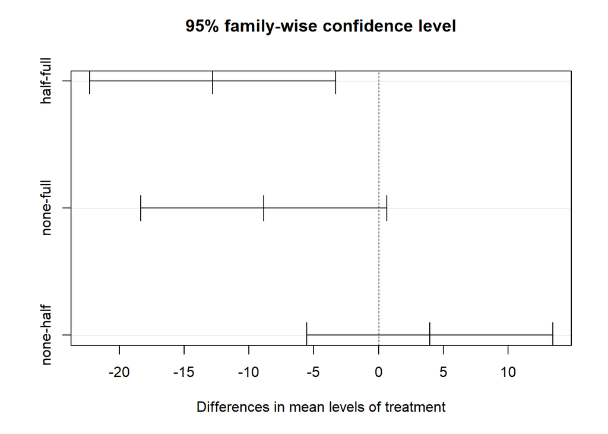

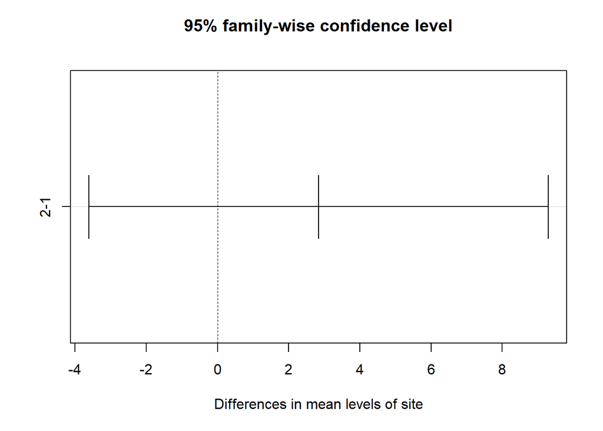

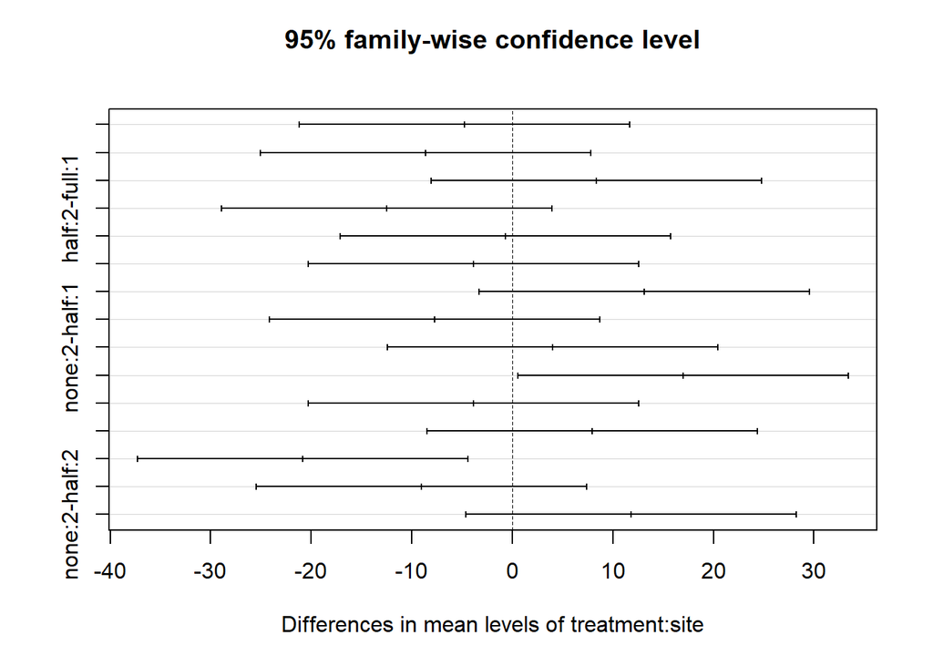

```r
plot(TukeyHSD(nnmod_treat_site))
```

```r
# For TDR and nn cover, the significant plots may explain results we see later, but the fact that there are 2-3 plots that are significantly different from each other doesn't tell us the sites or treatments are significantly different from each other.
```

4. figures

[figure not shown]

```r
# nnmod$site = as.factor(nnmod$site)

# boxplot: nncover x year
ggplot(data = nnmod, aes(x = year, y = nncover)) +
  geom_boxplot(aes(fill = year)) +
 # scale_fill_manual(values = c('#F19B34', '#9F7E75', '#92A587')) +
 # scale_fill_manual(values = c('#F6EECF', '#B09175', '#291611')) +
  labs(title = "Non-native cover by Site and Treatment", x = "Site", y = "Non-native cover (%)") +
  geom_smooth(method="lm") +
  theme_bw()
```

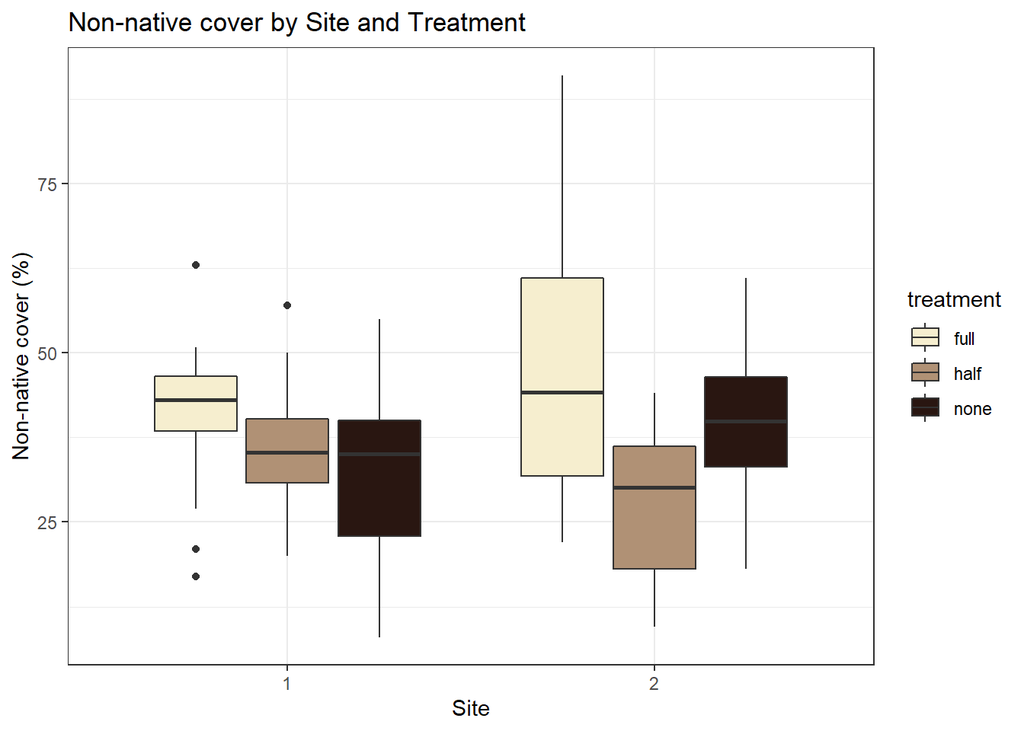

```r
# boxplot: nncover x site x treatment (no correlation)
nnmod$site = as.factor(nnmod$site)
ggplot(data = nnmod, aes(x = site, y = nncover)) +
  geom_boxplot(aes(fill = treatment)) +
 # scale_fill_manual(values = c('#F19B34', '#9F7E75', '#92A587')) +
  scale_fill_manual(values = c('#F6EECF', '#B09175', '#291611')) +
  labs(title = "Non-native cover by Site and Treatment", x = "Site", y = "Non-native cover (%)") +
  geom_smooth(method="lm") +
  theme_bw()
```

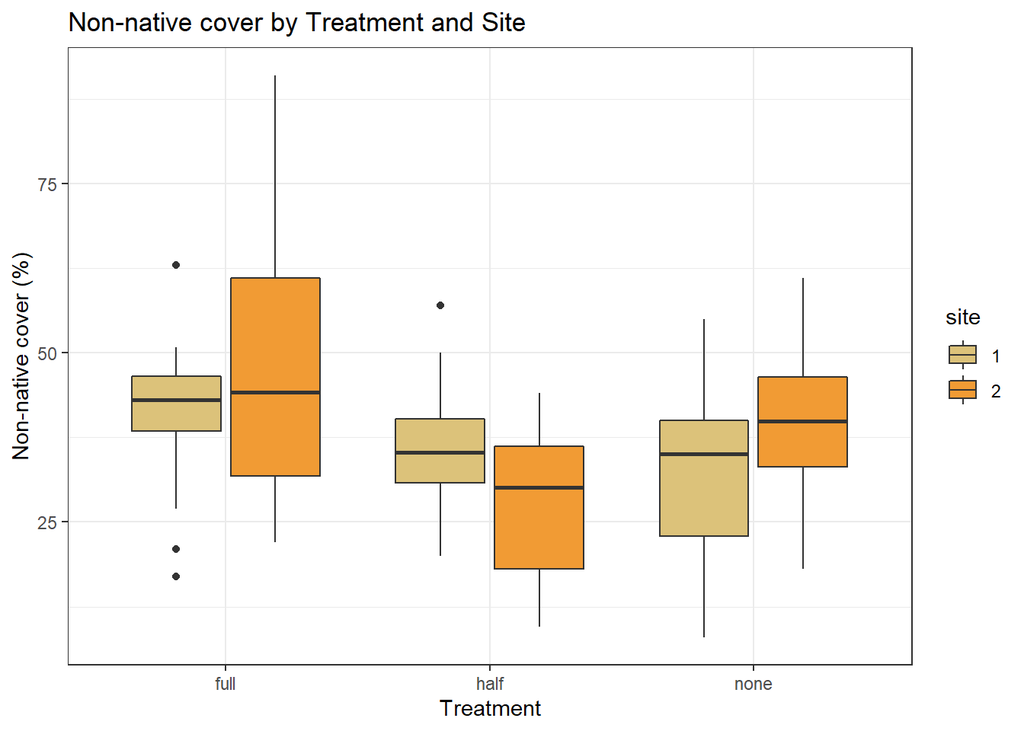

```r
# boxplot: mafacover x treatment x site (no correlation)
ggplot(data = nnmod, aes(x = treatment, y = nncover)) +
  geom_boxplot(aes(fill = site)) +
  geom_smooth(method="lm") +
  labs(title = "Non-native cover by Treatment and Site", x = "Treatment", y = "Non-native cover (%)") +
  scale_fill_manual(values = c(sitecolors)) +
  # scale_fill_manual(values = c('#D3E3CA', '#92A587')) +
  theme_bw()
```

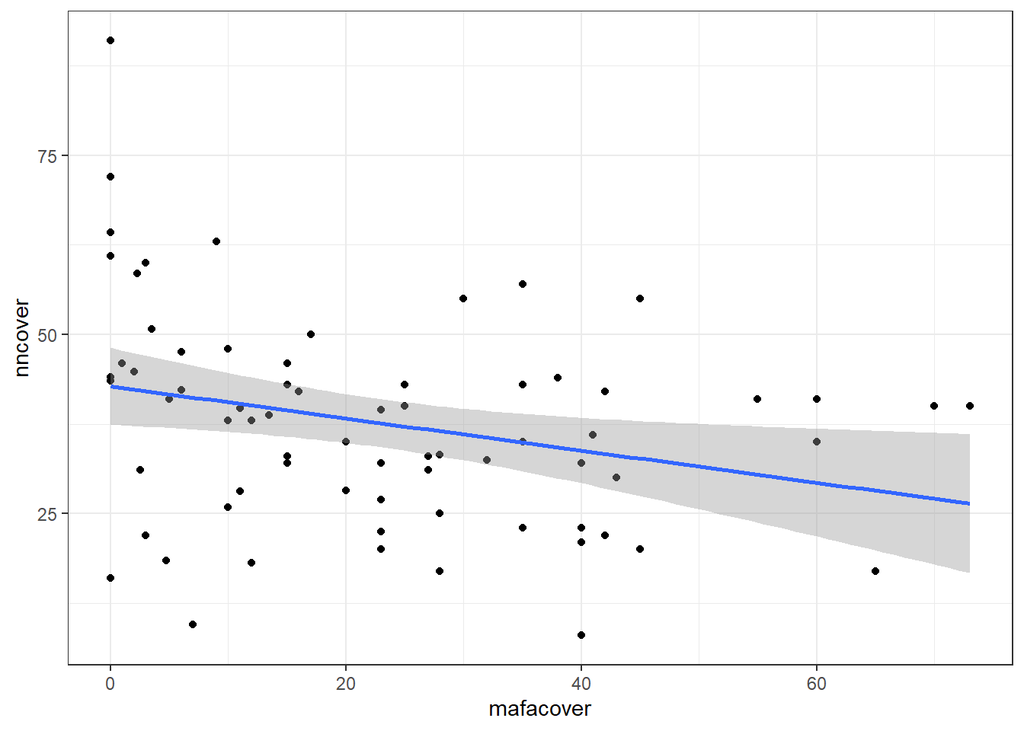

```r
# scatterplot: nncover x mafacover (no correlation)
ggplot(data = nnmod, aes(x = mafacover, y = nncover)) +
  geom_point() +
  geom_smooth(method="lm")+
  theme_bw()
```

# Question 1: Take aways

### PAR

- PAR is significantly correlated with MAFA cover.
- PAR is not correlated with treatment, site, or month.
- More canopy cover does mean more shade, and less canopy cover means more sun.
- No influence of month is expected since we normalized PAR values.

### TDR

- soil moisture is significantly correlated with site and treatment
- There are no effects of MAFA canopy cover, year, or month on soil moisture.
- Soil moisture is greater at Site 1 than at Site 2 by treatment (e.g., full removal at Site 1 has more soil moisture than full removal at Site 2)

### Non-native cover

- Non-native cover is not correlated with Treatment, Site, MAFA cover (%), or year.
- This could be because we measured non-native cover once a year at peak biomass/peak growth in May-June

# Question 2: How does seedling survival change by PAR, TDR, and mafacover?

Is canopy treatment or canopy cover a stronger predictor of the environmental conditions below the shrub canopy?

# Glossary

## *df exploration*

- *dim(df)* gives you number of rows and columns in the df
- *str(df)* gives you the structure of your dataframe
- *names(df)* will give you the column names in the df
- *install.packages()* to install packages
- *installed.packages()* to see what packages are installed
- *class(df)* to tell if df or tibble
  - df <- as_tibble(df) to turn into a tibble

## *dplyr*

- *filter()* for sub-setting row/observations
- *select()* for sub-setting columns/variables
- *mutate()* for transforming variables * df %>% mutatue(newcolumn_name = variable selection) * ==, <, >, can make multiple new columns within one mutate command
- *group_by(catvariable)* for numerical summaries of categories (e.g., site, treatment, species)
- *summarise(meansurvival = mean(survival), n = n())* for numerical summaries of observations (e.g., height, survival, percent cover) + n = n() will count total observations for your variable meanWage + creates a new tibble with a summary for each level
- *fivenum()* for all 5 summaries

## *statistics*

- lmer: Fit Linear Mixed-Effects Models
  - Fit a linear mixed-effects model (LMM) to data, via REML or maximum likelihood.
- letters
  - https://statdoe.com/cld-customisation/
- emmeans-package
  - emmeans() = Estimated marginal means
  - emtrends()
- ANOVA
  - result <- aov(response_variable ~ explanitory_variable, data = df) TukeyHSD(parmod_treatment) plot(TukeyHSD(parmod_treatment))
- t-test: compare the means of two groups
  - with data from two dfs –> t.test(par1$response_variable, par2(dollarsign)response_variable)
  - with data from one df –> t.test(normalized_par ~ year, data = parmod)

# Tips

*If things start to break*, run the code from the beginning. The environment may need to be cleared and reset. *DO NOT fix data in EXCEL.* Use R. Once you “finalize” your raw data, don’t touch it or re-save it. Doing that can change the column formatting, which can break your importing code.

**end of code**